# Scaling of Social Connections & Demographic Analysis

#### Ayush Sarkar: 5/15/2025 - 7/11/2025 | CLIMA w/ Dynamical Systems Lab @ NYU

*A study of how Facebook-derived social connectivity scales with population across U.S. counties and Core-Based Statistical Areas (CBSAs), paired with Census-block demographics of coastal NYC communities.*

# Objectives:

- **CiviL Infrastructure research for climate change Mitigation and Adaptation (CLIMA)** is a research effort focused on infrastructure research to help develop equitable and feasible solutions to the increasingly urgent threats *posed* by climate change through mitigating damages and adapting to hazards and changes across coastal communities.
- This leg of CLIMA is an interdisciplinary research project that aims to model the effects of flood risk on coastal communities through a detailed investigation of social networks, alongside other factors, in an attempt to create models that are more capable of capturing human mobility phenomena, especially amongst homeowners.
- By using a modified compartmental model, we can split the population into unique sets and utilize the mean-field hypothesis to treat individuals as identical, allowing us to focus on the population's dynamics instead of individual-level cognition. To better appreciate the unique perspectives of individuals and communities that face these threats, CLIMA also seeks to include qualitative information about the network extracted through interviews with homeowners of coastal communities here in NYC.
- Additionally, demographic breakdowns of the locations of study were done to further understand the context and everyday lives of the homeowners within these communities. On the quantitative side, we utilize more traditional methods, including historical Census data and related public data, to build a more comprehensive demographic profile.
- This **notebook specifically focuses on (1) the scaling of social connections with population** across counties and CBSAs, and **(2) demographic analyses** of the coastal NYC communities under study (with Hamilton Beach as the running example, and Red Hook as a comparison).

# List of Tasks:

1. Completed CITI training
2. Completed interview transcriptions
3. Computed scaling exponents for social connections vs. population at different administrative divisions in the US, including:
   - County-level
   - CBSA-level (combined Metropolitan + Micropolitan)
   - MSA-level (Metropolitan Statistical Area)
   - muSA-level (Micropolitan Statistical Area)
4. Attempted to perform community identification using Clique Percolation:
   - Unsuccessful due to hardware and time constraints on a ~10M-row symmetric edge list
5. Generated demographic analyses for the relevant coastal NYC communities (Hamilton Beach, Howard Beach, Red Hook)

# Table of Contents:

1. **Introduction:**
   - Datasets and their provenance
   - Preliminary notation and definitions
   - Network types (county- and CBSA-level)
   - SCI and connection equations
   - Urban scaling background
   - Improving $\beta$ via rescaling (per *Schläpfer et al.*)
2. **Data Cleaning & Exploration:**
   - Loading and cleaning the SCI, ESRI, crosswalk, and Census files
   - Choropleth maps for geographic visualization
   - Histograms with KDE and parametric PDF fits
3. **Scaling Results:**
   - Log-log linear regression plots at the County, CBSA, MSA, and muSA levels
   - Tabulated $\beta$ and $\gamma$ estimates with confidence intervals
4. **Demographic Analyses (Census Block resolution, NYC):**
   - Age/Sex population pyramids w/ NYC averages
   - Race/Ethnicity distribution w/ NYC averages
   - Persons per household (1-5+) distribution w/ NYC averages
   - Housing occupancy status distribution w/ NYC averages
   - Housing tenure (owner vs. renter) distribution w/ NYC averages
   - Pie charts of educational attainment and household income for Hamilton Beach and Red Hook
5. **Discussion, future work, and references**

# Quantitative Datasets:

## Datasets

1. **U.S. Bureau of Labor Statistics County-to-CBSA Crosswalk** — used to map counties to Core-Based Statistical Areas (CBSAs), and from there to MSAs vs. muSAs.
2. **ESRI 2022 Monthly Active Facebook Users and Population Estimates by County** — provides the user counts $|S_i|$ and population estimates $N_i$ that enter both the connection formulas and the coverage estimate $s_i$.
3. **Meta's Social Connectedness Index (SCI)** — the directional, county-to-county friendship-tie measure that anchors the entire connection calculation.
4. **Meta Public Coverage Estimates** — used as an external sanity check on our derived $s_i$ values.
5. **IPUMS NHGIS: Census Demographics Files at Census Block resolution** — for the demographic side of the project:
   - 2020 Decennial Census Demographic and Housing Characteristics (DHC):
     - `H3`: Housing Occupancy Counts
     - `H4`: Housing Tenure Counts
     - `H9`: Household Size Counts
     - `P3`: Race counts
     - `P5`: Hispanic or Latino origin by race
     - `P12`: Sex by age across the total population
   - `nhgis0004_ds267_20235`: Educational attainment and household income
6. **2021 County- and CBSA-level TIGER/Line shapefiles** for choropleths.

## Meta SCI

The [County-to-County data sheet](https://data.humdata.org/dataset/e9988552-74e4-4ff4-943f-c782ac8bca87/resource/c59fd5ac-0458-4e83-b6be-5334f0ea9a69/download/us-counties-us-counties-fb-social-connectedness-index-october-2021.zip) includes the following columns:

## ESRI 2022 Facebook Monthly Active Users (MAU) and Population Estimates

The [ESRI dataset](https://nyuds.maps.arcgis.com/home/item.html?id=14a2fb32e22b4fe5ab9d884c9e994075) is a multipurpose collection of market potential indices for various commercial services and goods, including Facebook MAU estimates. It also includes multiple GEOID resolutions (e.g., counties, blocks, ZCTAs). The columns of interest are:

1. `MP19049a_B` — 2022 Social Media: used Facebook in the last 30 days (our $|S_i|$)
2. `TOTPOP_CY` — 2022 total population (ESRI, non-Census) (our $N_i$)
3. `ID` — 2022 5-digit FIPS county code

We choose ESRI specifically because Meta does **not** publish official county-level MAU counts; the ESRI estimates are the best publicly available stand-in, which is what makes the coverage-rescaling step in *Schläpfer et al.* necessary in our setting.

## Meta Public Coverage Estimates:

[figure not shown]

# Preliminary Notation and Definitions:

A brief glossary so that the formulas below are easy to read. Throughout, "GEOID" refers generically to a geographic unit — usually a county (5-digit FIPS) or a CBSA (5-digit CBSA code). The subscript $i$ indexes an individual GEOID; the subscript on $k$ tags the *type* of degree being summed.

$$ \begin{align*} &{\large \textbf{Social Network Graph Notation}}\\ &G = \text{Whole social network graph (all counties, all edges)} \\ &C = \text{GEOID-level covering (e.g., the set of counties forming a single CBSA)} \\ &\tilde{C} = \text{Complement covering (all counties outside } C \text{)} \\ &n_{\text{GEOID}} = \text{Number of GEOID-level nodes} \in G \\\\ &{\large \textbf{Degree and Connection Notation}}\\ &k_{i,\,o} = \text{Outgoing degree of GEOID } i \text{ (cross-GEOID connections)} \\ &k_{i,\,ic} = \text{Inter-GEOID degree of GEOID } i \text{ (within-GEOID connections)} \\ &k_{i,\,t} = \text{Total degree of GEOID } i = k_{i,\,o} + k_{i,\,ic} \\ &K_{r,\,i} = \text{Rescaled cumulative degree of } i \text{ (i.e., } k_{i,\,t}/s_i \text{)} \\ &\langle K_{r}\rangle = \text{Average rescaled cumulative degree over all GEOIDs} \\\\ &{\large \textbf{User and Population Notation}}\\ &N_i = \text{Population estimate of GEOID } i \text{ (ESRI 2022)} \\ &\langle N\rangle = \text{Average GEOID population estimate} \\ &|S_i| = \text{2022 Facebook MAU estimate (30-day) for GEOID } i \\ &s_i = |S_i| / N_i = \text{Coverage estimate for GEOID } i \\\\ &{\large \textbf{Scaling Notation}}\\ &\beta = \text{Scaling exponent (slope in log-log space)} \\ &\gamma = \text{Intercept (in log-log space)} \end{align*} $$

> **A note on terminology:** in this notebook, "**Inter-**" is used to denote *within-GEOID* connections (i.e., $(i,i)$ pairs), while "**Outer-**" / "**Outgoing**" denote *cross-GEOID* connections (i.e., $(i,j)$ with $i \neq j$). This is non-standard — the prefix "inter-" conventionally means *between* — but it is internally consistent across the codebase, dataframe column names, and figures. If you are reading the variable `inter_county_connections`, that is the within-county degree.

# Network Types:

## County-level network types

At the **county level**, we partition connections into three disjoint types — **Inter**, **Outgoing**, and **Total** (= Inter + Outgoing). For the county-level graph $G_{\text{County}}$ and a fixed home county $i$:

- **Inter-county (within-county) connections**

  $$ E_{ic}(i) = \{(u, v) \mid u, v \in i,\ u \neq v\} \tag{Inter-County Conn.} $$
  - Connections between two users $u, v$ who both reside in county $i$. These are loops on the county node when the graph is contracted to county granularity.
- **Outgoing (cross-county) connections**

  $$ E_o(i) = \{(u, v) \mid u \in i,\ v \in j,\ j \neq i\} \tag{Outer-County Conn.} $$
  - Connections between a user $u$ in county $i$ and a user $v$ in some other county $j$.
- **Total county connections**

  $$ E_t(i) = E_{ic}(i) \;\cup\; E_o(i) \tag{Total County Conn.} $$
  - Every connection touching county $i$.

The cumulative degree $k_{i,\,t}$ is simply $|E_t(i)|$, and likewise for $k_{i,\,ic}$ and $k_{i,\,o}$.

## CBSA-level network types

At the **CBSA level**, the picture is one nesting deeper, because each CBSA is itself a covering $C$ over multiple counties. We define four CBSA-level types: **ICIC**, **ICCC**, **OCOC**, and **Total** (= ICIC + ICCC + OCOC).

- **Inter-covering inter-county (ICIC) — within-CBSA, within-county**

  $$ \textbf{ICIC}(C) = \bigcup_{i \in C} E_{ic}(i) \tag{ICIC CBSA Conn.} $$
  - Connections that live inside a single county *and* whose county sits inside the CBSA covering. Summed across all counties in $C$.
- **Inter-covering cross-county (ICCC) — within-CBSA, between-county**

  $$ \textbf{ICCC}(C) = \bigcup_{\substack{i,\,j \in C \\ i \neq j}} E_o(i)\big|_{j} \tag{ICCC CBSA Conn.} $$
  - Connections between two different counties $i \neq j$, both of which sit inside the same CBSA covering.
- **Outer-covering cross-county (OCOC) — outside-CBSA connections**

  $$ \textbf{OCOC}(C) = \bigcup_{\substack{i \in C \\ j \in \tilde{C}}} E_o(i)\big|_{j} \tag{Outer-CBSA Conn.} $$
  - Connections between a county $i$ inside the CBSA covering and a partner county $j$ outside it. This captures the "external reach" of a CBSA.
- **Total CBSA connections**

  $$ \textbf{Total}(C) = \textbf{ICIC}(C) \,\cup\, \textbf{ICCC}(C) \,\cup\, \textbf{OCOC}(C) \tag{Total CBSA Conn.} $$
  - The full degree of the CBSA in $G$. As we'll see in the next section, the fact that these three sets are *disjoint* is what lets us recover OCOC by subtraction instead of enumeration.

# Important Equations:

As a quick preface, the SCI equations come from Meta's [Social Connectedness Index Project documentation](https://data.humdata.org/dataset/e9988552-74e4-4ff4-943f-c782ac8bca87/resource/a0c37eb4-b45c-436d-b2b2-c0c9b1974318/download/documentation-fb-social-connectedness-index-october-2021.pdf). From these, we invert to solve for Facebook connection counts at the county level and then aggregate up to CBSAs.

- **Combinatorial refresher** $$ \binom{n}{k} := \frac{n!}{k!(n-k)!}, \quad n,k \in \mathbb{N} \tag{Combinations} $$
  - A Facebook connection involves exactly **two users**, so we set $k = 2$. The combination formula then answers: *given $n$ objects, how many unique unordered pairs can we form?*
  - There are two places this matters in our setup:

    **(1) Within-county user pairs.** With $|S_i|$ users in county $i$, the number of *ordered* (user, other user) pairs is $|S_i| \cdot (|S_i| - 1)$, exactly twice the unordered count $\binom{|S_i|}{2}$. Meta's homogeneous SCI formula uses the *ordered* count in its denominator, which is why the within-county connection equation below has $|S_i|(|S_i|-1)$ rather than $\binom{|S_i|}{2}$ — each Facebook friendship contributes one edge in each direction.

    **(2) Cross-county GEOID pairs in the SCI dataset.** Since $\text{SCI}_{i,j}$ is indexed by GEOIDs $i$ and $j$, the same accounting determines the *number of rows* in the SCI dataset. With $n_{\text{GEOID}}$ counties, symmetric off-diagonal entries (both $(i,j)$ and $(j,i)$ are recorded), and self-pairs $(i,i)$:

    $$ \text{SCI Row Entries} = 2 \cdot \binom{n_{\text{GEOID}}}{2} + n_{\text{GEOID}} = n_{\text{GEOID}}^2 \tag{Total SCI Row Entries} $$

    For $n_{\text{GEOID}} = 3{,}141$ cleaned U.S. counties, this gives $9{,}865{,}881$ rows, matching what we get after the cleaning step.

## SCI Equations:

- **Homogeneous SCI (within-county)** — represents the average connection density among ordered user pairs in a single county: $$ \text{SCI}_{i,i} = \frac{\text{FB Conn.}_{i,i}} {|S_i| \cdot (|S_i| - 1)} \tag{Homogeneous SCI} $$
- **Heterogeneous SCI (cross-county)** — represents the average connection density between two different counties: $$ \text{SCI}_{i,j} = \frac{\text{FB Conn.}_{i,j}} {|S_i| \cdot |S_j|} \tag{Heterogeneous SCI} $$

We *invert* these two relations to solve for the connection counts, which is what we actually want to study.

## Connections Equations:

### County-level connections:

- - **Inter-county Facebook connections** $$ \text{FB Conn.}_{i,i} = \text{SCI}_{i,i} \cdot \big(|S_i| \cdot (|S_i| - 1)\big) \tag{Inter-County Conn.} $$
  - **Outer-county (cross-county) Facebook connections** $$ \text{FB Conn.}_{i,j} = \text{SCI}_{i,j} \cdot \big(|S_i| \cdot |S_j|\big) \tag{Outgoing County Conn.} $$
  - **Total county-level Facebook connections** $$ \begin{align} \text{FB Conn.}_i &= \text{FB Conn.}_{i,i} + \sum_{\substack{j \in G_{\text{County}} \\ j \neq i}} \text{FB Conn.}_{i,j} \\ &= \text{SCI}_{i,i} \cdot \big(|S_i| \cdot (|S_i| - 1)\big) + \sum_{\substack{j \in \text{Counties} \\ j \neq i}} \text{SCI}_{i,j} \cdot |S_i| \cdot |S_j| \end{align} \tag{Total County Conn.} $$

### CBSA-level connections:

- SCI is only defined at county-to-county granularity, so the CBSA-level connection counts are *built up* by summing county-level connections across the counties belonging to each CBSA.
  - **Inter-covering inter-county CBSA-level connections (ICIC)** $$ \textbf{ICIC}_{C} = \sum_{i \in C} \text{SCI}_{i,i} \cdot |S_i| \cdot (|S_i| - 1) \tag{ICIC Conn.} $$
  - **Inter-covering cross-county CBSA-level connections (ICCC)** $$ \textbf{ICCC}_{C} = \sum_{\substack{i, j \in C \\ i \neq j}} \text{SCI}_{i,j} \cdot |S_i| \cdot |S_j| \tag{ICCC Conn.} $$
  - **Outer-covering CBSA-level connections (OCOC)** $$ \textbf{OCOC}_{C} = \sum_{\substack{i \in C,\ j \in \tilde{C}}} \text{SCI}_{i,j} \cdot |S_i| \cdot |S_j| \tag{Outer CBSA Conn.} $$
  - **Total CBSA-level Facebook connections** $$ \textbf{Total}_{C} = \textbf{ICIC}_{C} + \textbf{ICCC}_{C} + \textbf{OCOC}_{C} \tag{Total CBSA Conn.} $$

## Symmetry, SCI, and Connections:

- Since SCI is not defined at the CBSA level, we compute CBSA-level total connections by summing the total connections of all counties within the CBSA covering. This is valid because the total number of connections in the graph is **invariant under topological coverings** — that is, the number of connections does not change whether we consider county-level or CBSA-level partitions.
- This invariance lets us exploit the fact that, while the *distribution* of connections across county GEOIDs changes when we coarse-grain to CBSAs, the *total number of connections in $G$ is conserved*. As a result, we can algebraically recover **OCOC** in terms of **ICIC**, **ICCC**, and **Total**, rather than computing $\textbf{OCOC}_{C}$ directly.

  This approach is necessary due to the symmetry of FIPS code pairs in the SCI dataset:
  - Attempting to *unsymmetrize* the SCI dataset using the `user_loc` or `fr_loc` columns — by removing duplicate FIPS-FIPS pairs in either direction — introduces a bias toward whichever county's FIPS code happens to appear first in the dataframe (typically the lower-numbered one). This process also effectively converts the graph into an undirected one, since only $(i,j)$ would remain and not $(j,i)$. Depending on downstream merges or indexing operations, this can lead to significant issues. For this reason, **we keep the SCI dataset symmetric throughout the pipeline**.
  - Instead of iterating over the full dataframe and matching FIPS-FIPS pairs explicitly, we group counties by their CBSA codes and sum the total county-level connections (inter + outgoing) for all counties within each CBSA covering. From the disjoint partition $\textbf{Total}_{C} = \textbf{ICIC}_{C} + \textbf{ICCC}_{C} + \textbf{OCOC}_{C}$, we obtain:

  $$ \textbf{OCOC}_{C} = \textbf{Total}_{C} - \big[\textbf{ICIC}_{C} + \textbf{ICCC}_{C}\big] \tag{OCOC} $$

## Power-Law Scaling Relationships

- We begin by assuming a power-law relationship between the cumulative degree $k_{i,\,t}$ and the GEOID population $N_i$. This is the same functional form that has been observed empirically for face-to-face interactions in cities, GDP, patent counts, and a wide range of other urban metrics:

$$ k_{i,\,t} = N_i^{\beta} \cdot \epsilon_i \tag{Basic Power Law} $$

- Applying a log-log transformation (and treating $\epsilon_i$ as multiplicative noise so that $\log \epsilon_i$ is additive on the log scale), we proceed as: $$ \begin{align} \log(k_{i,\,t}) &= \log(N_{i}^{\beta}) + \log(\epsilon_i) \\\\ &= \beta \cdot \log(N_i) + \log(\epsilon_i) \end{align} \tag{Log-Linear Form} $$
- To recover the scaling exponent $\beta$ and the intercept $\gamma$, we plot each county/GEOID as a single point in the plane defined by two GEOID features (e.g., the number of connections vs. population, or — in classical allometry — metabolic rate vs. body mass).
- By plotting GEOID feature $y$ vs. GEOID feature $x$ for all available GEOIDs and fitting a regression, we are identifying a *national-level macroscopic trend* between two aggregate features — each county contributes one data point.
- We work in log-log space because logarithms convert proportional differences into additive ones, which is the natural representation for the multiplicative processes that pervade biology and the social sciences, and because they make the data scale-invariant: a doubling of population looks the same whether the baseline is 10,000 or 10,000,000.
- We then estimate the relationship using **linear regression**, producing a scatter plot with a line of best fit. The slope of this line, $\beta$, characterizes the power-law scaling relationship between cumulative degree and population:
  - **Superlinear:** $\beta > 1$ — bigger places generate *disproportionately* more connections per person (typical of within-city interaction, innovation, GDP)
  - **Linear:** $\beta = 1$ — connections scale exactly with population (per-capita rate is constant)
  - **Sublinear:** $\beta < 1$ — bigger places have *proportionally fewer* connections per person (typical of infrastructure economies of scale)
- This framework lays the foundation for understanding how social connectivity scales with population across counties.

## Improving $\beta$ via Rescaling

Following [*Schläpfer et al.*](https://doi.org/10.1098/rsif.2013.0789), we improve estimation of the scaling exponent $\beta$ by rescaling the cumulative degree $k_{i,\,t}$:

1. **Divide cumulative degree by the coverage estimate** of location $i$, denoted $s_i$. The motivation: our $k_{i,\,t}$ only counts connections among the Facebook-active subset of residents, so a county with low coverage will look artificially under-connected. Dividing by $s_i$ corrects for this sampling bias and recovers a quantity proportional to the true population-level degree.
2. **Normalize both population and rescaled cumulative degree by their averages**, which tightens the linear fit and raises the $R^2$ — geometrically, this re-centers the cloud of points on $(1, 1)$ so that the regression isn't sensitive to absolute units.

### County-level rescaling

We first apply this methodology at the county level. Since the SCI data are already at county-to-county resolution, no initial aggregation step is required.

1. **Compute county coverage estimates**

   $$ s_{\text{County}_i} = \frac{|S_i|}{N_i}, \quad \forall i \in G $$
2. **Rescale cumulative degree by coverage**

   $$ K_{r,\,\text{County}_i} = \frac{k_{i,\,t}^{(\text{County})}}{s_{\text{County}_i}} $$
3. **Compute averages of the rescaled degree and population over all counties**

   $$ \langle K_{r,\,\text{County}} \rangle = \frac{1}{n_{\text{County}}} \sum_{i=1}^{n_{\text{County}}} K_{r,\,\text{County}_i} $$

   $$ \langle N_{\text{County}} \rangle = \frac{1}{n_{\text{County}}} \sum_{i=1}^{n_{\text{County}}} N_{\text{County}_i} $$
4. **Normalize variables prior to fitting**
   - Normalize population:

     $$ N_{\text{County}_i} \;\leftarrow\; \frac{N_{\text{County}_i}}{\langle N_{\text{County}} \rangle} \tag{County Population Normalization} $$
   - Normalize rescaled cumulative degree:

     $$ K_{r,\,\text{County}_i} \;\leftarrow\; \frac{K_{r,\,\text{County}_i}} {\langle K_{r,\,\text{County}} \rangle} \tag{Rescaled County Degree} $$
5. **Estimate $\beta$**

   Each county is plotted as a point in the plane of log-transformed, normalized, rescaled cumulative degree vs. log-transformed, normalized population. An OLS fit (`statsmodels`) yields a line of best fit whose slope $\beta$ characterizes the scaling relationship:
   - **Superlinear:** $\beta > 1$
   - **Linear:** $\beta = 1$
   - **Sublinear:** $\beta < 1$

### CBSA-level rescaling

The same procedure carries over to CBSAs once we've aggregated county-level user and population estimates up to the CBSA covering.

1. **Aggregate county-level user and population estimates**

   $$ |S|_{\text{CBSA}} = \sum_{i \in C_{\text{CBSA}}} |S_i|, \qquad N_{\text{CBSA}} = \sum_{i \in C_{\text{CBSA}}} N_i $$
2. **Compute CBSA coverage estimates**

   $$ s_{\text{CBSA}} = \frac{|S|_{\text{CBSA}}}{N_{\text{CBSA}}} $$
3. **Rescale CBSA cumulative degree**

   $$ K_{r,\,\text{CBSA}} = \frac{k_t^{(\text{CBSA})}}{s_{\text{CBSA}}} $$
4. **Compute averages of the rescaled degree and population over all CBSAs**

   $$ \langle K_{r,\,\text{CBSA}} \rangle = \frac{1}{n_{\text{CBSA}}}\sum_{i=1}^{n_{\text{CBSA}}} K_{r,\,\text{CBSA}_i} $$

   $$ \langle N_{\text{CBSA}} \rangle = \frac{1}{n_{\text{CBSA}}}\sum_{i=1}^{n_{\text{CBSA}}} N_{\text{CBSA}_i} $$
5. **Normalize variables prior to fitting** — analogous to steps 4a/4b above, but with CBSA averages.
6. **Estimate $\beta$**

   Each CBSA is plotted as a point in the plane of log-transformed, normalized, rescaled cumulative degree vs. log-transformed, normalized population. The OLS fit yields a best-fit line whose slope $\beta$ characterizes the scaling at the CBSA level. When we compute MSA-only and muSA-only fits, we re-take the averages using *only* MSAs (or *only* muSAs) so that the normalization is internal to each subpopulation and not contaminated by the size mismatch between metropolitan and micropolitan areas.

# Code:

The remainder of this notebook is the executable implementation of the framework above. Cells are organized so that:

1. **Requirements** — libraries and raw datasets are loaded once.
2. **Data Cleaning** — the SCI, ESRI, and crosswalk files are merged into the four export dataframes (`df_outer_county`, `df_cbsa`, `df_msa`, `df_musa`) that all downstream sections consume.
3. **Data Exploration** — histograms with KDE/parametric fits and choropleth maps inspect the distributions and geographic structure of connections.
4. **Scaling** — log-log OLS regressions produce the $\beta$ estimates summarized in the results table at the bottom of the notebook.
5. **Demographics** — Census-block-level analyses of the Hamilton Beach (and comparison) communities.

The scripts under `scripts/` mirror these cells one-to-one and can be run standalone if you prefer not to re-execute the notebook.

## Requirements:

`pandas`, `numpy`, `matplotlib`, `geopandas`, `scipy`, `statsmodels`, and `scikit-learn`. The choropleth section additionally uses `esda` for Moran's I (commented out by default), and reads TIGER/Line shapefiles via `geopandas.read_file`. Memory note: the raw SCI TSV is ~180 MB and decompresses to a ~10M-row dataframe — be mindful when running this on a constrained machine.

### Libraries:

All the third-party packages we'll need across data cleaning, statistical fitting, and plotting. We import them up front so each downstream cell can be run in isolation after the kernel restarts.

```python
import pandas as pd
import numpy as np
import matplotlib.pyplot as plt
import matplotlib.cm as cm
import geopandas as gpd
import math
from matplotlib.lines import Line2D
from matplotlib.patches import Patch
from scipy.stats import lognorm, skewnorm, genpareto, norm, gaussian_kde
from matplotlib.ticker import FixedLocator, FixedFormatter
from matplotlib.colors import Normalize
from matplotlib.patches import Patch
```

### Data Sets:

Load every raw source in one place so the rest of the notebook is decoupled from file paths. `dtype=str` is used wherever a column will eventually be a FIPS code or GEOID, because pandas would otherwise drop the leading zeros that matter for joining (e.g., `01001` for Autauga County, AL).

```python
df_sci = pd.read_table('F:\\dsl_CLIMA\\Social Connectdness Data\\County-County Data\\county_county.tsv', dtype=str)
df_users = pd.read_csv('F:\\dsl_CLIMA\\arcGIS User Data\\county_users.csv', dtype=str)
df_crosswalk = pd.read_excel('F:\\dsl_CLIMA\\MSAs and MicroSAs\\Census Data\\list1.xls', header=2, dtype=str)
df_tenure = pd.read_csv('F:\\dsl_CLIMA\\projects\\submittable\\clima\\source\\census demographic files\\DECENNIALDHC2020.H4-Data.csv', dtype={'GEO_ID':str, 'NAME':str})
df_household_size = pd.read_csv('F:\\dsl_CLIMA\\projects\\submittable\\clima\\source\\census demographic files\\DECENNIALDHC2020.H9-Data.csv', dtype={'GEO_ID':str, 'NAME':str})
df_sex_by_age = pd.read_csv('F:\\dsl_CLIMA\\projects\\submittable\\clima\\source\\census demographic files\\DECENNIALDHC2020.P12-Data.csv', dtype={'GEO_ID':str, 'NAME':str})
df_race = pd.read_csv('F:\\dsl_CLIMA\\projects\\submittable\\clima\\source\\census demographic files\\DECENNIALDHC2020.P3-Data.csv', dtype={'GEO_ID':str, 'NAME':str})
df_hispanic = pd.read_csv('F:\\dsl_CLIMA\\projects\\submittable\\clima\\source\\census demographic files\\DECENNIALDHC2020.P5-Data.csv', dtype={'GEO_ID':str, 'NAME':str})
df_occupancy = pd.read_csv('F:\\dsl_CLIMA\\projects\\submittable\\clima\\source\\census demographic files\\DECENNIALDHC2020.H3-Data.csv', dtype={'GEO_ID':str, 'NAME':str})
gdf_county = gpd.read_file('F:\\dsl_CLIMA\\projects\\submittable\\clima\\source\\shape files\\county\\tl_2021_us_county.shp')
gdf_cbsa = gpd.read_file('F:\\dsl_CLIMA\\projects\\submittable\\clima\\source\\shape files\\cbsa\\tl_2021_us_cbsa.shp')
```

## Data Cleaning:

This cell takes the raw SCI, ESRI, and BLS crosswalk files and produces the four export dataframes that the rest of the notebook (and the standalone scripts) consume:

- `df_inner_county` — one row per county, with `inter_county_connections` (within), `outer_county_connections` (cross-county sum), `total connections`, plus `user_est`, `pop_est`, `coverage est`, and CBSA metadata.
- `df_cbsa` — one row per CBSA, with the three CBSA-level connection types (ICIC, ICCC, OCOC), plus aggregated `user_est` / `pop_est` and rescaled / normalized variants used for the regressions.
- `df_msa`, `df_musa` — subsets of `df_cbsa` for which the normalization averages have been recomputed *within* the metropolitan-only and micropolitan-only subpopulations, respectively, so each fit is internally consistent.

Notable manual fixes inside this cell:

- **Alaskan census-area reorganization**: `02261` (Valdez-Cordova) was split into `02063` (Chugach) and `02066` (Copper River) after the 2020 redistricting. We re-merge them into `02261` so the SCI (which still uses the pre-split codes' replacement) joins cleanly to ESRI.
- **`15005` Kalawao County, HI** is dropped — it has a population in the low double digits and breaks log-scale plots.

```python
import pandas as pd
import numpy as np

df_sci = pd.read_table('F:\\dsl_CLIMA\\projects\\submittable\\clima\\source\\sci\\county_county.tsv', dtype=str)
df_users = pd.read_csv('F:\\dsl_CLIMA\\projects\\submittable\\clima\\source\\users\\county_users.csv', dtype=str)
df_crosswalk = pd.read_excel('F:\\dsl_CLIMA\\projects\\submittable\\clima\\source\\crosswalk\\list1.xls', header=2, dtype=str)

df_crosswalk = df_crosswalk.iloc[:-3]
df_crosswalk['FIPS'] = df_crosswalk['FIPS State Code'] + df_crosswalk['FIPS County Code']
df_crosswalk['FIPS'] = df_crosswalk['FIPS'].astype(str).str.zfill(5)
df_crosswalk = df_crosswalk[['FIPS','CBSA Code', 'Metropolitan/Micropolitan Statistical Area', 'CBSA Title']].copy()

df_users = df_users[['MP19049a_B', 'TOTPOP_CY', 'ID']]
df_users = df_users.rename(columns={'MP19049a_B': 'user_count','TOTPOP_CY': 'pop','ID': 'FIPS'})

df_users['FIPS'] = df_users['FIPS'].astype(str).str.zfill(5)
df_users['user_count'] = pd.to_numeric(df_users['user_count'], errors='coerce')
df_users['pop']  = pd.to_numeric(df_users['pop'], errors='coerce')

df_users = df_users.set_index('FIPS')
df_users = df_users.groupby(df_users.index)[['user_count', 'pop']].sum()

# Chugach + Copperhead Census Areas = Valdez-Cordova Census Area (after 2020)
df_users.loc['02261'] = df_users.loc[['02066', '02063']].sum()
df_users = df_users.drop(index=['02066', '02063', '15005']) # 15005 is Kalawao County in Hawaii

df_sci = df_sci[df_sci['user_loc'].isin(df_users.index) & df_sci['fr_loc'].isin(df_users.index)]
df_sci['scaled_sci'] = df_sci['scaled_sci'].astype(float)
df_sci['scaled_sci'] = df_sci['scaled_sci']/1000000000
df_sci['user_user_count'] = df_sci['user_loc'].map(df_users['user_count'])
df_sci['user_pop'] = df_sci['user_loc'].map(df_users['pop'])
df_sci['fr_user_count'] = df_sci['fr_loc'].map(df_users['user_count'])
df_sci['fr_pop'] = df_sci['fr_loc'].map(df_users['pop'])

df_sci['Connections'] = np.where(df_sci['user_loc'] == df_sci['fr_loc'], df_sci['scaled_sci'] * (df_sci['user_user_count'] * (df_sci['user_user_count'] - 1)), df_sci['scaled_sci'] * df_sci['user_user_count'] * df_sci['fr_user_count'])
df_county = df_sci.merge(df_crosswalk, left_on = 'user_loc', right_on = 'FIPS', how = 'left', suffixes=('', '_user')).copy()
df_county = df_county.merge(df_crosswalk, left_on = 'fr_loc', right_on = 'FIPS', how = 'left', suffixes=('', '_fr')).copy()

df_county['user_user_count'] = pd.to_numeric(df_county['user_user_count'], errors='coerce')
df_county['user_pop']  = pd.to_numeric(df_county['user_pop'], errors='coerce')

df_inner_county = (
    df_county[(df_county["user_loc"] == df_county["fr_loc"])]
    .groupby("user_loc", as_index=False)
    .agg(
        user_est=("user_user_count", "first"),
        pop_est=("user_pop", "first"),
        metro_micro_area=("Metropolitan/Micropolitan Statistical Area", "first"),
        CBSA_code=("CBSA Code", "first"),
        CBSA_title=("CBSA Title", "first"),
        inter_county_connections=("Connections", "first"),
    )
).copy()

df_outer_county = (
    df_county[(df_county["user_loc"] != df_county["fr_loc"])]
    .groupby("user_loc", as_index=False)
    .agg(outer_county_connections=("Connections", "sum"))
).copy()

df_inner_county['outer_county_connections'] = df_outer_county['outer_county_connections']
df_inner_county['total connections'] = df_outer_county['outer_county_connections'] + df_inner_county['inter_county_connections']

df_inter_county_inter_cbsa = (df_county[
        (df_county["CBSA Code"] == df_county["CBSA Code_fr"]) &
        (df_county["user_loc"] == df_county["fr_loc"])
    ]
    .groupby("CBSA Code", as_index=False)
    .agg(
        CBSA_title=("CBSA Title", "first"),
        metro_micro_area=("Metropolitan/Micropolitan Statistical Area", "first"),
        user_est=("user_user_count", "sum"),
        pop_est=("user_pop", "sum"),
        inter_cbsa_connections=("Connections", "sum"),
        )
).copy()

df_outer_county_inter_cbsa = (
    df_county[df_county["CBSA Code"] == df_county["CBSA Code_fr"]]
    .query("user_loc != fr_loc")
    .groupby("CBSA Code", as_index=False)
    .agg(outer_county_inter_cbsa_connections=("Connections", "sum"))
).copy()

df_outer_cbsa = (
       df_county[
        (df_county["CBSA Title"] != df_county["CBSA Title_fr"]) &
        (df_county["user_loc"] != df_county["fr_loc"])
    ]
    .groupby("CBSA Code", as_index=False)
    .agg(outer_cbsa_connections=("Connections", "sum"))
).copy()

df_cbsa = df_inter_county_inter_cbsa.merge(df_outer_county_inter_cbsa, on='CBSA Code', how='left').merge(df_outer_cbsa, on='CBSA Code', how='left')

df_cbsa['total inter_cbsa connections'] = np.where(
    df_county.groupby('CBSA Code')['user_loc'].nunique() == 1,
    df_cbsa['inter_cbsa_connections'],
    df_cbsa['inter_cbsa_connections'] + df_cbsa['outer_county_inter_cbsa_connections']
)

df_cbsa['total connections'] = df_cbsa['total inter_cbsa connections'] + df_cbsa['outer_cbsa_connections']
df_cbsa['coverage est'] = df_cbsa['user_est']/df_cbsa['pop_est']

df_cbsa['rescaled total inter_cbsa connections'] = df_cbsa['total inter_cbsa connections']/df_cbsa['coverage est']
df_cbsa['rescaled outer_cbsa_connections'] = df_cbsa['outer_cbsa_connections']/df_cbsa['coverage est']
df_cbsa['rescaled total connections'] = df_cbsa['total connections']/df_cbsa['coverage est']

df_msa = df_cbsa[df_cbsa['metro_micro_area'] == 'Metropolitan Statistical Area'].copy()
df_musa = df_cbsa[df_cbsa['metro_micro_area'] == 'Micropolitan Statistical Area'].copy()
df_msa['normed pop_est'] = (df_msa['pop_est']/(df_msa['pop_est'].mean()))
df_musa['normed pop_est'] = (df_musa['pop_est']/(df_musa['pop_est'].mean()))
df_cbsa['normed pop_est'] = (df_cbsa['pop_est']/(df_cbsa['pop_est'].mean()))

df_msa['rescaled total inter_cbsa connections'] = df_msa['rescaled total inter_cbsa connections']/df_msa['rescaled total inter_cbsa connections'].mean()
df_msa['rescaled outer_cbsa_connections'] = df_msa['rescaled outer_cbsa_connections']/df_msa['rescaled outer_cbsa_connections'].mean()
df_msa['rescaled total connections'] = df_msa['rescaled total connections']/df_msa['rescaled total connections'].mean()

df_musa['rescaled total inter_cbsa connections'] = df_musa['rescaled total inter_cbsa connections']/df_musa['rescaled total inter_cbsa connections'].mean()
df_musa['rescaled outer_cbsa_connections'] = df_musa['rescaled outer_cbsa_connections']/df_musa['rescaled outer_cbsa_connections'].mean()
df_musa['rescaled total connections'] = df_musa['rescaled total connections']/df_musa['rescaled total connections'].mean()

df_cbsa['rescaled total inter_cbsa connections'] = df_cbsa['rescaled total inter_cbsa connections']/df_cbsa['rescaled total inter_cbsa connections'].mean()
df_cbsa['rescaled outer_cbsa_connections'] = df_cbsa['rescaled outer_cbsa_connections']/df_cbsa['rescaled outer_cbsa_connections'].mean()
df_cbsa['rescaled total connections'] = df_cbsa['rescaled total connections']/df_cbsa['rescaled total connections'].mean()

df_inner_county['coverage est'] = df_inner_county['user_est']/df_inner_county['pop_est']
df_inner_county['normed pop_est'] = (df_inner_county['pop_est']/(df_inner_county['pop_est'].mean()))

df_inner_county['rescaled inter_county_connections'] = df_inner_county['inter_county_connections']/df_inner_county['coverage est']
df_inner_county['rescaled outer_county_connections'] = df_inner_county['outer_county_connections']/df_inner_county['coverage est']
df_inner_county['rescaled total connections'] = df_inner_county['total connections']/df_inner_county['coverage est']

df_inner_county['rescaled inter_county_connections'] = df_inner_county['rescaled inter_county_connections']/df_inner_county['rescaled inter_county_connections'].mean()
df_inner_county['rescaled outer_county_connections'] = df_inner_county['rescaled outer_county_connections']/df_inner_county['rescaled outer_county_connections'].mean()
df_inner_county['rescaled total connections'] = df_inner_county['rescaled total connections']/df_inner_county['rescaled total connections'].mean()

df_inner_county.to_csv('F:\\dsl_CLIMA\\projects\\submittable\\clima\\export\\df_outer_county.csv', index=False)
df_cbsa.to_csv('F:\\dsl_CLIMA\\projects\\submittable\\clima\\export\\df_cbsa.csv', index=False)
df_msa.to_csv('F:\\dsl_CLIMA\\projects\\submittable\\clima\\export\\df_msa.csv', index=False)
df_musa.to_csv('F:\\dsl_CLIMA\\projects\\submittable\\clima\\export\\df_musa.csv', index=False)
```

## Data Exploration:

Before fitting any regressions, we want to verify that the cleaned data behaves the way the literature suggests: heavy-tailed distributions of connections, roughly log-normal user/population marginals, and visible geographic structure in the connection counts. The next two subsections — histograms and choropleths — are about building that confidence.

### Distributions and Histograms:

For each of the connection / user / population / coverage variables — at the County, CBSA, MSA, and muSA levels — we plot a histogram with:

- A non-parametric **Gaussian KDE** as the empirical reference PDF.
- Parametric fits suggested by the urban-scaling literature, evaluated against that KDE via RMSE.
- The 25th and 75th percentiles shaded, plus markers for the mean and median.

The point is two-fold: (1) confirm that the variables we're about to log-transform are well-suited to a log-log fit (i.e., they look log-normal or close to it), and (2) flag any GEOIDs that sit deep in the tails so we know what's pulling the regression around.

**Quick Notes:**

1. We choose parametric PDFs in line with the documentation of [*Schläpfer et al.*](https://doi.org/10.1098/rsif.2013.0789), and with what is typically found when describing social and urban networks:
   - **Normal** — sanity-check baseline; if the data is genuinely log-normal in the original units, the *log-transformed* histogram should look approximately Normal.
   - **Log-Normal** — the most common candidate for connection counts (multiplicative growth processes).
   - **Skew-Normal** — accommodates the moderate asymmetry typical of these distributions without the heavy tails of a Pareto.
   - **Generalized Pareto (fit on the top 75% tail, i.e., values above the 25th percentile)** — captures tail behavior without assuming the tail starts at zero.
2. To form a non-parametric PDF of best fit for each histogram, I use a Gaussian-kernel **KDE**. I then compare the parametric PDFs above to the KDE PDF by computing the **root mean squared error (RMSE)** at the bin centers. The lowest-RMSE parametric is reported as the closest fit. This is a deliberately simple comparison — it doesn't penalize parameter count or test goodness-of-fit formally — but it is enough to flag which of the canonical PDFs is *closest* to what the data look like.

```python
import pandas as pd
import numpy as np
import math
import matplotlib.pyplot as plt
from matplotlib.lines import Line2D
from matplotlib.patches import Patch
from scipy.stats import lognorm, skewnorm, genpareto, norm, gaussian_kde

df_inner_county = pd.read_csv('F:\\dsl_CLIMA\\projects\\submittable\\clima\\export\\df_outer_county.csv')
df_cbsa = pd.read_csv('F:\\dsl_CLIMA\\projects\\submittable\\clima\\export\\df_cbsa.csv')
df_msa = pd.read_csv('F:\\dsl_CLIMA\\projects\\submittable\\clima\\export\\df_msa.csv')
df_musa = pd.read_csv('F:\\dsl_CLIMA\\projects\\submittable\\clima\\export\\df_musa.csv')
df_sci = pd.read_table('F:\\dsl_CLIMA\\projects\\submittable\\clima\\source\\sci\\county_county.tsv', dtype={'user_loc':str, 'fr_loc':str, 'scaled_sci':int})

# Helper function to arrange subplots in a rectangular format
def near_square_grid(k, min_cols=3):
    cols = max(min_cols, math.ceil(np.sqrt(k)))
    rows = math.ceil(k / cols)
    return rows, cols

def plot_histograms_with_pdfs_kde(
    dfs, cols, titles=None, x_labels=None, log_x=False, no_log_cols=None,
    figsize_per_plot=4, bar_padding=0.03,
    title_fontsize=12, stats_fontsize=10, legend_fontsize=9,
    box_alpha=0.15,
    bin_max=None,
    kde_max=None
):
    if titles is None:
        titles = cols
    if x_labels is None:
        x_labels = cols

    k = len(cols)
    rows, cols_n = near_square_grid(k, min_cols=3)

    fig, axes = plt.subplots(
        rows, cols_n,
        figsize=(cols_n * figsize_per_plot * 1.3, rows * figsize_per_plot * 1.15),
        squeeze=False,
        constrained_layout=True
    )
    axes = axes.flatten()

    for idx, (ax, df_sub, col, title, xlabel) in enumerate(
        zip(axes, dfs, cols, titles, x_labels)
    ):

        # ---------- Data handling ----------
        raw_data = df_sub[col].dropna().values

        use_log = log_x
        if no_log_cols is not None:
            if col in no_log_cols or idx in no_log_cols:
                use_log = False

        if use_log:
            raw_data = raw_data[raw_data > 0]
            data = np.log10(raw_data)
        else:
            data = raw_data

        if len(data) < 5:
            ax.axis('off')
            continue

        mean_val = np.mean(data)
        median_val = np.median(data)
        variance_val = np.var(data)
        q25, q75 = np.percentile(data, [25, 75])

        # ---------- Freedman–Diaconis bins (capped) ----------
        h = 2 * (q75 - q25) / len(data) ** (1/3)
        if h <= 0 or not np.isfinite(h):
            bins = 'auto'
        else:
            bins = int(np.ceil((data.max() - data.min()) / h))

        if bin_max is not None:
            bins = min(bins, bin_max)

        counts, bin_edges, patches = ax.hist(
        data,
        bins=bins,
        density=True,
        alpha=0.6,
        color='skyblue',
        edgecolor='black'
        )

        bin_centers = (bin_edges[:-1] + bin_edges[1:]) / 2

        # ---------- Percentile shading ----------
        for i, patch in enumerate(patches):
            if bin_centers[i] <= q25:
                patch.set_facecolor('lightcoral')
                patch.set_alpha(0.4)
            elif bin_centers[i] >= q75:
                patch.set_facecolor('plum')
                patch.set_alpha(0.4)

        # ---------- KDE (subsampled) ----------
        if kde_max is not None and len(data) > kde_max:
            kde_data = np.random.choice(data, kde_max, replace=False)
        else:
            kde_data = data


        kde = gaussian_kde(kde_data)
        x_kde = np.linspace(data.min(), data.max(), 500)
        y_kde = kde(x_kde)
        ax.plot(x_kde, y_kde, color='black', lw=2, label='KDE')

        # ---------- Parametric fits ----------
        fitted_pdfs = {}

        mu, sigma = norm.fit(data)
        fitted_pdfs['Normal'] = norm.pdf(bin_centers, mu, sigma)

        a, loc_sn, scale_sn = skewnorm.fit(data)
        fitted_pdfs['SkewNormal'] = skewnorm.pdf(bin_centers, a, loc_sn, scale_sn)

        if use_log:
            shape, loc, scale = lognorm.fit(raw_data, floc=0)
            fitted_pdfs['LogNormal'] = (
                lognorm.pdf(10**bin_centers, shape, loc, scale)
                * np.log(10)
                * 10**bin_centers
            )

        # ---------- Tail detection & GenPareto ----------
        tail_q = 25
        u = np.percentile(raw_data, tail_q)
        tail_raw = raw_data[raw_data > u] - u

        u_plot = np.log10(u) if use_log else u
        dist_left = u_plot - data.min()
        dist_right = data.max() - u_plot
        tail_side = 'right' if dist_right < dist_left else 'left'

        if len(tail_raw) > 10:
            c, loc_gp, scale_gp = genpareto.fit(tail_raw, floc=0)

            tail_mask = (10**bin_centers > u) if use_log else (bin_centers > u)
            x_tail = (
                10**bin_centers[tail_mask] - u
                if use_log else
                bin_centers[tail_mask] - u
            )

            pdf_gp = (
                genpareto.pdf(x_tail, c, loc_gp, scale_gp)
                * (np.log(10) * 10**bin_centers[tail_mask] if use_log else 1.0)
            )

            gp_full = np.zeros_like(bin_centers)
            gp_full[tail_mask] = pdf_gp
            fitted_pdfs['GenPareto (25% Tail)'] = gp_full

        # ---------- Plot PDFs ----------
        for name, pdf in fitted_pdfs.items():
            ax.plot(bin_centers, pdf, lw=2, label=name)

        # ---------- RMSE vs KDE ----------
        kde_vals = kde(bin_centers)
        metrics = {
            name: np.sqrt(np.mean((pdf - kde_vals) ** 2))
            for name, pdf in fitted_pdfs.items()
        }

        stats_lines = ["RMSE of KDE vs PDF Estimates:"]
        for name, rmse in sorted(metrics.items(), key=lambda x: x[1]):
            stats_lines.append(f"{name}: {rmse:.4f}")

        stats_lines.append(f"\nMean: {mean_val:.4f}")
        stats_lines.append(f"Median: {median_val:.4f}")
        stats_lines.append(f"Variance: {variance_val:.4f}")

        ax.scatter(mean_val, kde(mean_val), color='red', s=80, zorder=5, label='Mean')
        ax.scatter(median_val, kde(median_val), color='darkgreen', s=80, zorder=5, label='Median')
```

```python
        # ---------- Legend & stats ----------
        if tail_side == 'right':
            stats_x, stats_ha = 0.02, 'left'
            legend_loc = 'upper left'
        else:
            stats_x, stats_ha = 0.98, 'right'
            legend_loc = 'upper right'

        hist_proxy = Patch(
            facecolor='skyblue',
            edgecolor='black',
            alpha=0.6,
            label='Histogram (25–75%)'
        )

        # Get existing handles FIRST
        handles, labels = ax.get_legend_handles_labels()

        # Now construct legend entries explicitly
        handles = (
            [hist_proxy]
            + handles
            + [
                Patch(facecolor='lightcoral', edgecolor='black', label='≤25th percentile'),
                Patch(facecolor='plum', edgecolor='black', label='≥75th percentile')
            ]
        )

        legend = ax.legend(
            handles=handles,
            fontsize=legend_fontsize,
            loc=legend_loc,
            frameon=True
        )

        fig = ax.figure
        fig.canvas.draw()
        legend_bbox = legend.get_window_extent().transformed(ax.transAxes.inverted())
        stats_y = legend_bbox.y0 - 0.04

        ax.text(
            stats_x,
            stats_y,
            "\n".join(stats_lines),
            transform=ax.transAxes,
            fontsize=stats_fontsize,
            va='top',
            ha=stats_ha,
            bbox=dict(facecolor='white', alpha=box_alpha, edgecolor='black')
        )

        # ---------- Labels ----------
        ax.set_title(title, fontsize=title_fontsize, pad=5)
        ax.set_xlabel(f"$\log_{{10}}$({xlabel})" if use_log else xlabel, fontsize=12)
        if use_log:
            ax.set_ylabel(r'Density per $\log_{10}$(unit)', fontsize=12)
        else:
            ax.set_ylabel('Density')

    for ax in axes[k:]:
        ax.axis('off')

    # ---------- Horizontal separators between rows ----------
    for row in range(1, rows):
        # Get all axes in the row above
        axes_above = axes[(row - 1)*cols_n : row*cols_n]

        # Find the bottom y-coordinate of the row above
        # We'll take the minimum y0 among axes in that row
        y_bottom = min(ax.get_position().y0 for ax in axes_above)

        # Create a line spanning the full figure width
        line = Line2D(
            [0, 1],             # x from left to right of figure
            [y_bottom - bar_padding - 0.0255],  # slightly below bottom of row
            transform=fig.transFigure,
            color='black',
            linewidth=1.5,
            clip_on=False
        )
        fig.add_artist(line)

    return fig, axes


### ------------ Connectivity & User Count histograms ------------ ###

# --- County-level SCI histograms ---
df_dedup = (
    df_sci
    .assign(
        loc_min=np.minimum(df_sci['user_loc'], df_sci['fr_loc']),
        loc_max=np.maximum(df_sci['user_loc'], df_sci['fr_loc'])
    )
    .drop_duplicates(subset=['loc_min', 'loc_max'])
    .drop(columns=['loc_min', 'loc_max'])
)
df_endo = (df_dedup[df_dedup['user_loc'] == df_dedup['fr_loc']]).copy()
df_exo = (df_dedup[df_dedup['user_loc'] != df_dedup['fr_loc']]).copy()

fig, axes = plot_histograms_with_pdfs_kde(
    dfs = [df_endo, df_exo, df_dedup],
    cols=['scaled_sci', 'scaled_sci', 'scaled_sci'],
    titles=
        ['$\log_{10}$(Inner-County SCI) per County', '$\log_{10}$(Outgoing County SCI) per County',
         '$\log_{10}$(Total County SCI) per County'],
    x_labels=['Inner-County SCI', 'Outgoing County SCI', 'Total County SCI'],
    log_x=True,
    figsize_per_plot=5,
    bar_padding=0.02,
    title_fontsize=16,
    stats_fontsize=8,
    legend_fontsize=9,
    bin_max=65,
    kde_max=200000
)
plt.show()
fig.savefig("F:\\dsl_CLIMA\\projects\\submittable\\clima\\plots\\histograms\\connectivity\\sci\\sci_histograms.png", dpi=800, bbox_inches='tight')

# --- County-level Connection histograms ---
fig, axes = plot_histograms_with_pdfs_kde(
    dfs=[df_inner_county]*6,
    cols=['inter_county_connections', 'outer_county_connections', 'total connections', 'user_est', 'pop_est', 'coverage est'],
    titles=
        ['$\log_{10}$(Inner-County Connections) per County', '$\log_{10}$(Outgoing County Connections) per County',
         '$\log_{10}$(Total County Connections) per County', '$\log_{10}$(User Estimate) per County',
         '$\log_{10}$(Population Estimate) per County', 'Coverage Estimate per County'],
    x_labels=['Inner-County Connections', 'Outgoing County Connections', 'Total County Connections',
              'County User Estimates', 'County Population Estimates', 'County Coverage Estimates'],
    no_log_cols=['coverage est'],
    log_x=True,
    figsize_per_plot=5,
    bar_padding=0.02,
    title_fontsize=16,
    stats_fontsize=8,
    legend_fontsize=9
)
plt.show()
fig.savefig("F:\\dsl_CLIMA\\projects\\submittable\\clima\\plots\\histograms\\connectivity\\connections\\county_connections_histograms.png", dpi=800, bbox_inches='tight')

# --- CBSA-level Connection, User, Population, & Coverage Estimate histograms ---
fig, axes = plot_histograms_with_pdfs_kde(
    dfs=[df_cbsa]*6,
    cols=['total inter_cbsa connections', 'outer_cbsa_connections', 'total connections',
          'user_est', 'pop_est', 'coverage est'],
    titles=
        ['$\log_{10}$(Inner-CBSA Connections) per CBSA', '$\log_{10}$(Outgoing CBSA Connections) per CBSA',
         '$\log_{10}$(Total CBSA Connections) per CBSA', '$\log_{10}$(User Estimate) per CBSA',
         '$\log_{10}$(Population Estimate) per CBSA', 'Coverage Estimate per CBSA'],
    x_labels=['Inner-CBSA Connections', 'Outgoing CBSA Connections', 'Total CBSA Connections',
              'CBSA User Estimates', 'CBSA Population Estimates', 'CBSA Coverage Estimates'],
    no_log_cols=['coverage est'],
    log_x=True,
    figsize_per_plot=5,
    bar_padding=0.02,
    title_fontsize=16,
    stats_fontsize=8,
    legend_fontsize=9
)
plt.show()
fig.savefig("F:\\dsl_CLIMA\\projects\\submittable\\clima\\plots\\histograms\\connectivity\\connections\\cbsa_connections_histograms.png", dpi=800, bbox_inches='tight')
```

```python
# --- MSA-level Connection, User, Population, & Coverage Estimate histograms ---
fig, axes = plot_histograms_with_pdfs_kde(
    dfs=[df_cbsa]*6,
    cols=['total inter_cbsa connections', 'outer_cbsa_connections', 'total connections',
          'user_est', 'pop_est', 'coverage est'],
    titles=
        ['$\log_{10}$(Inner-MSA Connections) per MSA', '$\log_{10}$(Outgoing MSA Connections) per MSA',
         '$\log_{10}$(Total MSA Connections) per MSA', '$\log_{10}$(User Estimate) per MSA',
         '$\log_{10}$(Population Estimate) per MSA', 'Coverage Estimate per MSA'],
    x_labels=['Inner-MSA Connections', 'Outgoing MSA Connections', 'Total MSA Connections',
              'MSA User Estimates', 'MSA Population Estimates', 'MSA Coverage Estimates'],
    no_log_cols=['coverage est'],
    log_x=True,
    figsize_per_plot=5,
    bar_padding=0.02,
    title_fontsize=16,
    stats_fontsize=8,
    legend_fontsize=9
)
plt.show()
fig.savefig("F:\\dsl_CLIMA\\projects\\submittable\\clima\\plots\\histograms\\connectivity\\connections\\msa_connections_histograms.png", dpi=800, bbox_inches='tight')

# --- muSA-level Connection, User, Population, & Coverage Estimate histograms ---
fig, axes = plot_histograms_with_pdfs_kde(
    dfs=[df_cbsa]*6,
    cols=['total inter_cbsa connections', 'outer_cbsa_connections', 'total connections',
          'user_est', 'pop_est', 'coverage est'],
    titles=
        ['$\log_{10}$(Inner-muSA Connections) per muSA', '$\log_{10}$(Outgoing muSA Connections) per muSA',
         '$\log_{10}$(Total muSA Connections) per muSA', '$\log_{10}$(User Estimate) per muSA',
         '$\log_{10}$(Population Estimate) per muSA', 'Coverage Estimate per muSA'],
    x_labels=['Inner-muSA Connections', 'Outgoing muSA Connections', 'Total muSA Connections',
              'muSA User Estimates', 'muSA Population Estimates', 'muSA Coverage Estimates'],
    no_log_cols=['coverage est'],
    log_x=True,
    figsize_per_plot=5,
    bar_padding=0.02,
    title_fontsize=16,
    stats_fontsize=8,
    legend_fontsize=9
)
plt.show()
fig.savefig("F:\\dsl_CLIMA\\projects\\submittable\\clima\\plots\\histograms\\connectivity\\connections\\musa_connections_histograms.png", dpi=800, bbox_inches='tight')

### ------------ Connectivity per Capita/User Count histograms ------------ ###

df_inner_county['inter_county_connections per capita'] = df_inner_county['inter_county_connections']/df_inner_county['pop_est']
df_inner_county['inter_county_connections per user'] = df_inner_county['inter_county_connections']/df_inner_county['user_est']

df_inner_county['outer_county_connections per capita'] = df_inner_county['outer_county_connections']/df_inner_county['pop_est']
df_inner_county['outer_county_connections per user'] = df_inner_county['outer_county_connections']/df_inner_county['user_est']

df_inner_county['total connections per capita'] = df_inner_county['total connections']/df_inner_county['pop_est']
df_inner_county['total connections per user'] = df_inner_county['total connections']/df_inner_county['user_est']


df_cbsa['inter_cbsa_connections per capita'] = df_cbsa['total inter_cbsa connections']/df_cbsa['pop_est']
df_cbsa['inter_cbsa_connections per user'] = df_cbsa['total inter_cbsa connections']/df_cbsa['user_est']

df_cbsa['outer_cbsa_connections per capita'] = df_cbsa['outer_cbsa_connections']/df_cbsa['pop_est']
df_cbsa['outer_cbsa_connections per user'] = df_cbsa['outer_cbsa_connections']/df_cbsa['user_est']

df_cbsa['total connections per capita'] = df_cbsa['total connections']/df_cbsa['pop_est']
df_cbsa['total connections per user'] = df_cbsa['total connections']/df_cbsa['user_est']


df_msa['inter_cbsa_connections per capita'] = df_msa['total inter_cbsa connections']/df_msa['pop_est']
df_msa['inter_cbsa_connections per user'] = df_msa['total inter_cbsa connections']/df_msa['user_est']

df_msa['outer_cbsa_connections per capita'] = df_msa['outer_cbsa_connections']/df_msa['pop_est']
df_msa['outer_cbsa_connections per user'] = df_msa['outer_cbsa_connections']/df_msa['user_est']

df_msa['total connections per capita'] = df_msa['total connections']/df_msa['pop_est']
df_msa['total connections per user'] = df_msa['total connections']/df_msa['user_est']


df_musa['inter_cbsa_connections per capita'] = df_musa['total inter_cbsa connections']/df_musa['pop_est']
df_musa['inter_cbsa_connections per user'] = df_musa['total inter_cbsa connections']/df_musa['user_est']

df_musa['outer_cbsa_connections per capita'] = df_musa['outer_cbsa_connections']/df_musa['pop_est']
df_musa['outer_cbsa_connections per user'] = df_musa['outer_cbsa_connections']/df_musa['user_est']

df_musa['total connections per capita'] = df_musa['total connections']/df_musa['pop_est']
df_musa['total connections per user'] = df_musa['total connections']/df_musa['user_est']

# --- County-level Connection histograms ---
fig, axes = plot_histograms_with_pdfs_kde(
    dfs=[df_inner_county]*6,
    cols=['inter_county_connections per capita', 'outer_county_connections per capita', 'total connections per capita', 'inter_county_connections per user', 'outer_county_connections per user', 'total connections per user'],
    titles=
        ['$\log_{10}$(Inner-County Connections per Capita) per County', '$\log_{10}$(Outgoing County Connections per Capita) per County',
         '$\log_{10}$(Total County Connections per Capita) per County', '$\log_{10}$(Inner-County Connections per User) per County',
         '$\log_{10}$(Outgoing County Connections per User) per County', '$\log_{10}$(Total County Connections per User) per County',],
    x_labels=['Inner-County Connections per Capita', 'Outgoing County Connections per Capita', 'Total County Connections per Capita',
              'Inner-County Connections per User', 'Outgoing County Connections per User', 'Total County Connections per User'],
    log_x=True,
    figsize_per_plot=5,
    bar_padding=0.02,
    title_fontsize=16,
    stats_fontsize=8,
    legend_fontsize=9
)
plt.show()
fig.savefig("F:\\dsl_CLIMA\\projects\\submittable\\clima\\plots\\histograms\\per_capita & per_user\\county_connections_histograms.png", dpi=800, bbox_inches='tight')
```

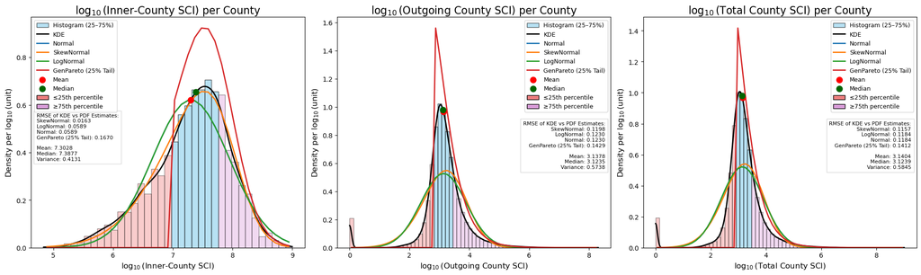

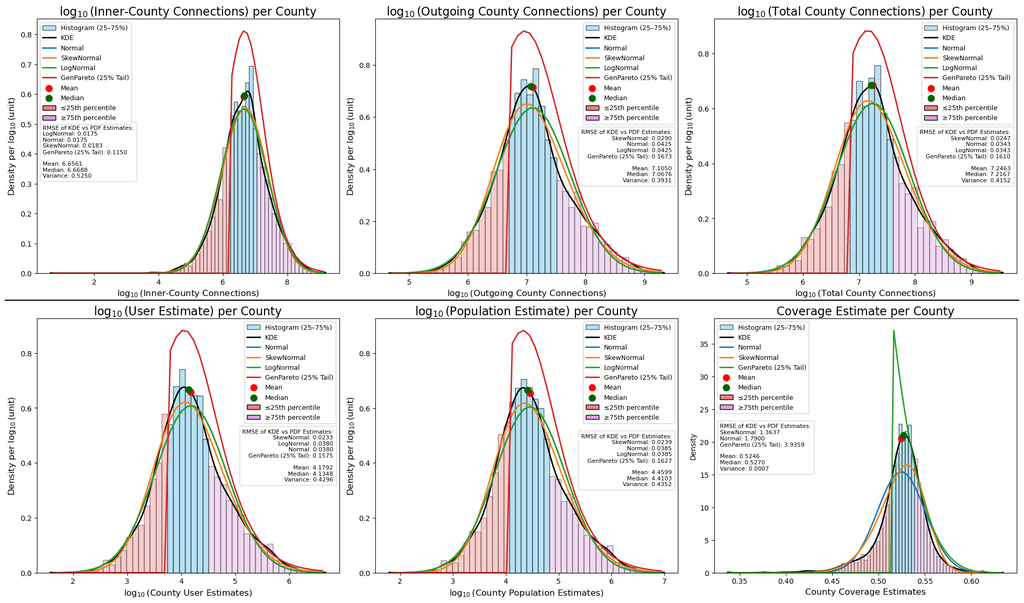

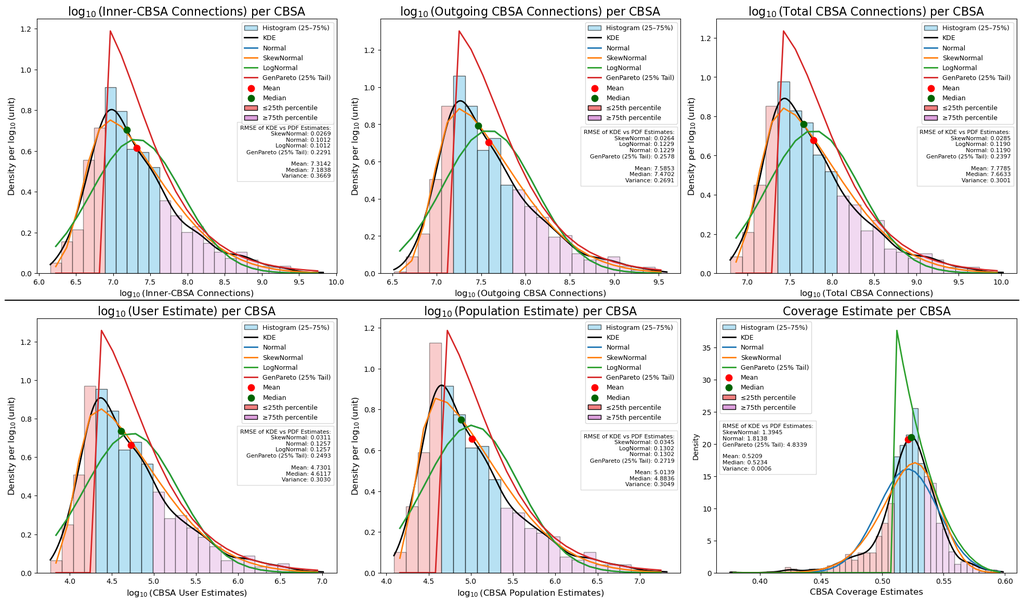

[figure not shown]

[figure not shown]

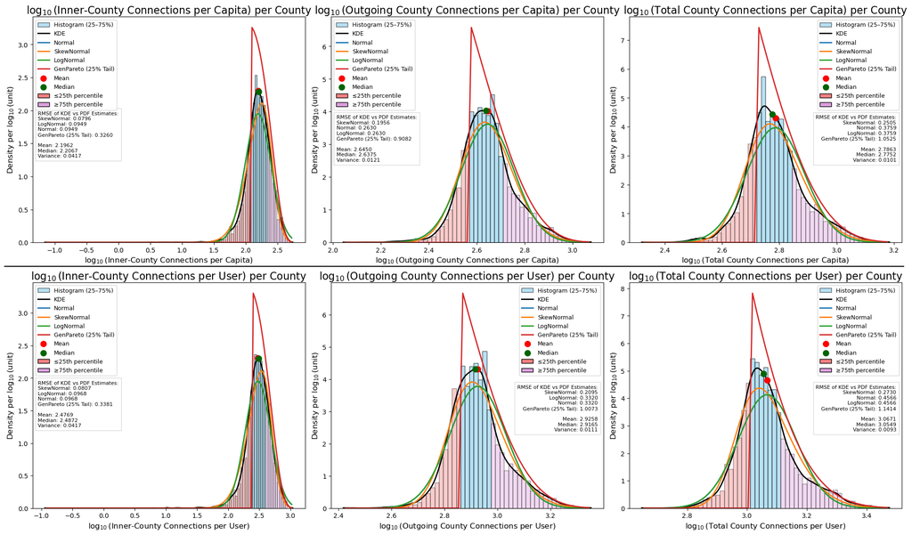

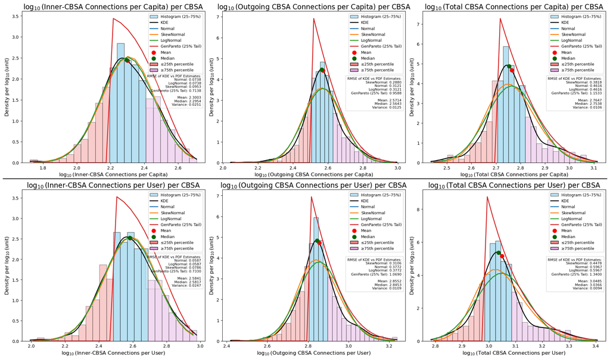

[figure not shown]

[figure not shown]

```python
# --- CBSA-level Connection, User, Population, & Coverage Estimate histograms ---
fig, axes = plot_histograms_with_pdfs_kde(
    dfs=[df_cbsa]*6,
    cols=['inter_cbsa_connections per capita', 'outer_cbsa_connections per capita', 'total connections per capita',
          'inter_cbsa_connections per user', 'outer_cbsa_connections per user', 'total connections per user'],
    titles=
        ['$\log_{10}$(Inner-CBSA Connections per Capita) per CBSA', '$\log_{10}$(Outgoing CBSA Connections per Capita) per CBSA',
         '$\log_{10}$(Total CBSA Connections per Capita) per CBSA', '$\log_{10}$(Inner-CBSA Connections per User) per CBSA',
         '$\log_{10}$(Outgoing CBSA Connections per User) per CBSA', '$\log_{10}$(Total CBSA Connections per User) per CBSA',],
    x_labels=['Inner-CBSA Connections per Capita', 'Outgoing CBSA Connections per Capita', 'Total CBSA Connections per Capita',
              'Inner-CBSA Connections per User', 'Outgoing CBSA Connections per User', 'Total CBSA Connections per User'],
    log_x=True,
    figsize_per_plot=5,
    bar_padding=0.02,
    title_fontsize=16,
    stats_fontsize=8,
    legend_fontsize=9
)
plt.show()
fig.savefig("F:\\dsl_CLIMA\\projects\\submittable\\clima\\plots\\histograms\\per_capita & per_user\\cbsa_connections_histograms.png", dpi=800, bbox_inches='tight')

# --- MSA-level Connection, User, Population, & Coverage Estimate histograms ---
fig, axes = plot_histograms_with_pdfs_kde(
    dfs=[df_cbsa]*6,
    cols=['inter_cbsa_connections per capita', 'outer_cbsa_connections per capita', 'total connections per capita',
          'inter_cbsa_connections per user', 'outer_cbsa_connections per user', 'total connections per user'],
    titles=
        ['$\log_{10}$(Inner-MSA Connections per Capita) per MSA', '$\log_{10}$(Outgoing MSA Connections per Capita) per MSA',
         '$\log_{10}$(Total MSA Connections per Capita) per MSA', '$\log_{10}$(Inner-MSA Connections per User) per MSA',
         '$\log_{10}$(Outgoing MSA Connections per User) per MSA', '$\log_{10}$(Total MSA Connections per User) per MSA',],
     x_labels=['Inner-MSA Connections per Capita', 'Outgoing MSA Connections per Capita', 'Total MSA Connections per Capita',
              'Inner-MSA Connections per User', 'Outgoing MSA Connections per User', 'Total MSA Connections per User'],
    log_x=True,
    figsize_per_plot=5,
    bar_padding=0.02,
    title_fontsize=16,
    stats_fontsize=8,
    legend_fontsize=9
)
plt.show()
fig.savefig("F:\\dsl_CLIMA\\projects\\submittable\\clima\\plots\\histograms\\per_capita & per_user\\msa_connections_histograms.png", dpi=800, bbox_inches='tight')

# --- muSA-level Connection, User, Population, & Coverage Estimate histograms ---
fig, axes = plot_histograms_with_pdfs_kde(
    dfs=[df_cbsa]*6,
    cols=['inter_cbsa_connections per capita', 'outer_cbsa_connections per capita', 'total connections per capita',
          'inter_cbsa_connections per user', 'outer_cbsa_connections per user', 'total connections per user'],
    titles=
        ['$\log_{10}$(Inner-muSA Connections per Capita) per muSA', '$\log_{10}$(Outgoing muSA Connections per Capita) per muSA',
         '$\log_{10}$(Total muSA Connections per Capita) per muSA', '$\log_{10}$(Inner-muSA Connections per User) per muSA',
         '$\log_{10}$(Outgoing muSA Connections per User) per muSA', '$\log_{10}$(Total muSA Connections per User) per muSA',],
    x_labels=['Inner-muSA Connections per Capita', 'Outgoing muSA Connections per Capita', 'Total muSA Connections per Capita',
              'Inner-muSA Connections per User', 'Outgoing muSA Connections per User', 'Total muSA Connections per User'],
    log_x=True,
    figsize_per_plot=5,
    bar_padding=0.02,
    title_fontsize=16,
    stats_fontsize=8,
    legend_fontsize=9
)
plt.show()
fig.savefig("F:\\dsl_CLIMA\\projects\\submittable\\clima\\plots\\histograms\\per_capita & per_user\\musa_connections_histograms.png", dpi=800, bbox_inches='tight')
```

### Scaling Exponent Estimation and log-log Regression plots:

This is the headline analysis of the notebook. For each region type (County, CBSA, MSA, muSA) and each network type (Inter / Outgoing / Total), we:

1. Drop any rows where the regressor or response is non-positive (log is undefined there).
2. Log-transform both the normalized rescaled cumulative degree $K_r / \langle K_r \rangle$ and the normalized population $N / \langle N \rangle$.
3. Fit an OLS line using `statsmodels`, reporting $\beta$ (slope), $\gamma$ (intercept), $R^2$, RMSE, RSE, and the 95% CIs on both parameters.
4. Overlay the mean, median, and modal data points to give a visual sense of where the bulk of the GEOID distribution sits along the fit.

The slope $\beta$ is the quantity we care about — its position relative to 1 tells us whether social connectivity scales superlinearly, linearly, or sublinearly with population. The 95% CI on $\beta$ tells us whether the difference from 1 is statistically meaningful.

```
C:\Users\Ayush Sarkar\AppData\Local\Temp\ipykernel_26324\3187359919.py:146: UserWarning: The figure layout has changed to tight
  plt.tight_layout()
```

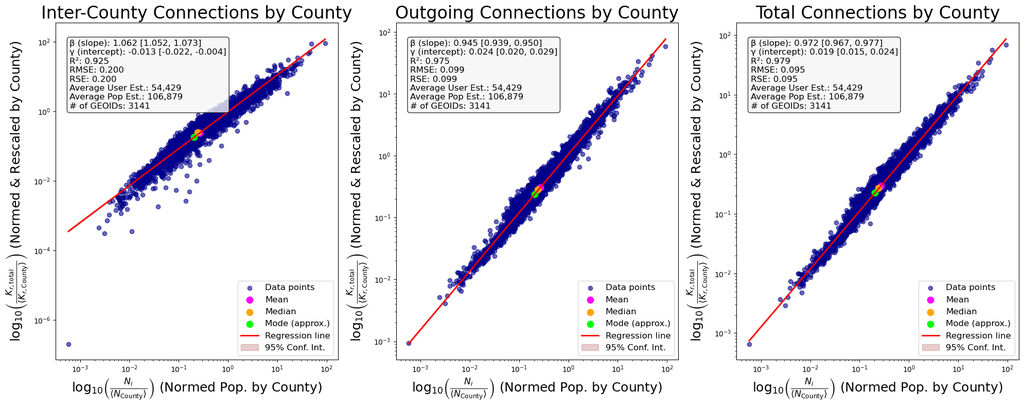

```
C:\Users\Ayush Sarkar\AppData\Local\Temp\ipykernel_26324\3187359919.py:179: UserWarning: The figure layout has changed to tight
  plt.tight_layout()
```

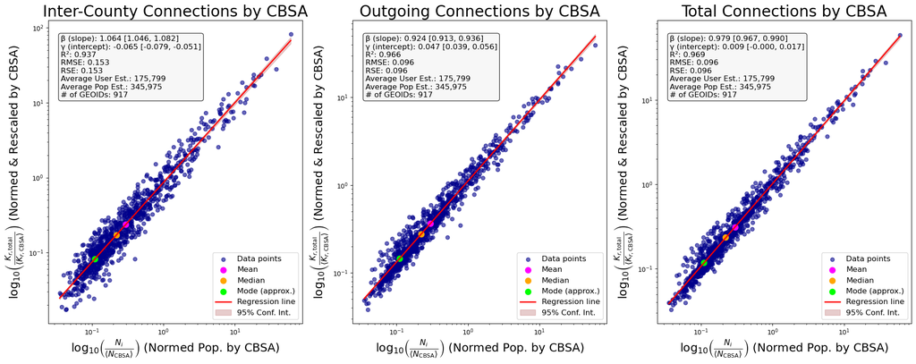

```
C:\Users\Ayush Sarkar\AppData\Local\Temp\ipykernel_26324\3187359919.py:212: UserWarning: The figure layout has changed to tight
  plt.tight_layout()
```

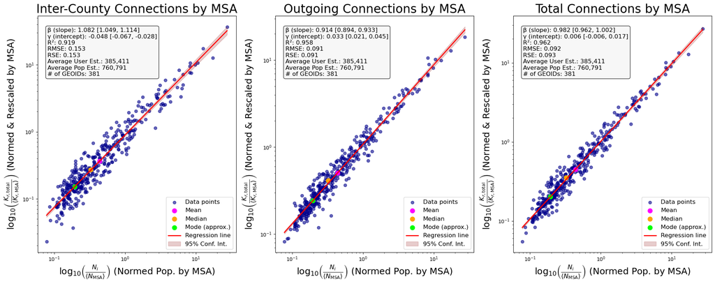

```
C:\Users\Ayush Sarkar\AppData\Local\Temp\ipykernel_26324\3187359919.py:245: UserWarning: The figure layout has changed to tight
  plt.tight_layout()
```

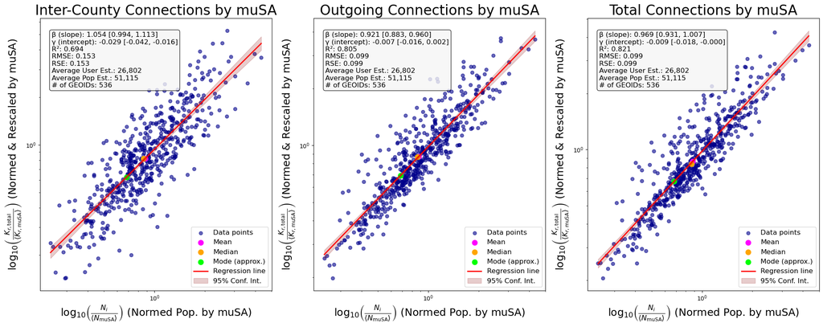

```python
import pandas as pd
import numpy as np
import matplotlib.pyplot as plt
import scipy.stats as stats
import statsmodels.api as sm
from sklearn.metrics import mean_squared_error

df_inner_county = pd.read_csv('F:\\dsl_CLIMA\\projects\\submittable\\clima\\export\\df_outer_county.csv')
df_cbsa = pd.read_csv('F:\\dsl_CLIMA\\projects\\submittable\\clima\\export\\df_cbsa.csv')
df_msa = pd.read_csv('F:\\dsl_CLIMA\\projects\\submittable\\clima\\export\\df_msa.csv')
df_musa = pd.read_csv('F:\\dsl_CLIMA\\projects\\submittable\\clima\\export\\df_musa.csv')

def log_log_regression_plot_on_ax(df, x_col, y_col, ax, title=None, region=''):
    df_plot = df[[x_col, y_col, 'user_est', 'pop_est']].copy()
    df_plot = df_plot[(df_plot[x_col] > 0) & (df_plot[y_col] > 0)]
    N = len(df_plot)

    if N < 2:
        raise ValueError("Not enough positive entries to fit regression.")

    x = np.log10(df_plot[x_col].values)
    y = np.log10(df_plot[y_col].values)

    x_with_const = sm.add_constant(x)
    model = sm.OLS(y, x_with_const)
    results = model.fit()

    slope = results.params[1]
    intercept = results.params[0]
    r2 = results.rsquared

    se = results.bse
    t_val = stats.t.ppf(0.975, df=N - 2)

    slope_ci = slope + np.array([-1, 1]) * t_val * se[1]
    intercept_ci = intercept + np.array([-1, 1]) * t_val * se[0]

    x_fit = np.linspace(x.min(), x.max(), 200)
    y_fit = intercept + slope * x_fit

    y_pred_fit = results.get_prediction(sm.add_constant(x_fit))
    y_ci = y_pred_fit.conf_int(alpha=0.05)

    y_hat = results.predict(x_with_const)
    rmse = np.sqrt(mean_squared_error(y, y_hat))
    rse = np.sqrt(np.sum((y - y_hat) ** 2) / (N - 2))

    # Statistics
    mean_x, mean_y = np.mean(x), np.mean(y)
    median_x, median_y = np.median(x), np.median(y)
    var_x, var_y = np.var(x, ddof=1), np.var(y, ddof=1)

    # Mode approximation for x
    hist, bin_edges = np.histogram(x, bins='auto')
    mode_bin = np.argmax(hist)
    mode_x = (bin_edges[mode_bin] + bin_edges[mode_bin + 1]) / 2
    mode_y = intercept + slope * mode_x

    # Plot points
    ax.scatter(10**x, 10**y, color='darkblue', alpha=0.6, label='Data points')
    ax.scatter(10**mean_x, 10**mean_y, color='fuchsia', s=80, label='Mean')
    ax.scatter(10**median_x, 10**median_y, color='orange', s=80, label='Median')
    ax.scatter(10**mode_x, 10**mode_y, color='lime', s=80, label='Mode (approx.)')

    # Regression line and confidence interval
    ax.plot(10**x_fit, 10**y_fit, color='red', lw=2, label='Regression line')
    ax.fill_between(
        10**x_fit,
        10**y_ci[:, 0],
        10**y_ci[:, 1],
        color='darkred',
        alpha=0.2,
        label='95% Conf. Int.'
    )

    ax.set_xscale('log')
    ax.set_yscale('log')

    ax.set_xlabel(
        rf'$\log_{{10}}\!\left(\frac{{N_i}}{{\langle N_{{\mathrm{{{region}}}}}\rangle}}\right)$ (Normed Pop. by {region})',
        fontsize=18
    )
    ax.set_ylabel(
        rf'$\log_{{10}}\!\left(\frac{{K_{{r,\mathrm{{total}}}}}}{{\langle K_{{r,\mathrm{{{region}}}}}\rangle}}\right)$ (Normed & Rescaled by {region})',
        fontsize=18
    )

    if title:
        ax.set_title(title, fontsize=24)

    ax.tick_params(axis='both', labelsize=10)

    # Legend/statistics text
    legend_text = (
        f"β (slope): {slope:.3f} [{slope_ci[0]:.3f}, {slope_ci[1]:.3f}]\n"
        f"γ (intercept): {intercept:.3f} [{intercept_ci[0]:.3f}, {intercept_ci[1]:.3f}]\n"
        f"R²: {r2:.3f}\n"
        f"RMSE: {rmse:.3f}\n"
        f"RSE: {rse:.3f}\n"
        f"Average User Est.: {df_plot['user_est'].mean():,.0f}\n"
        f"Average Pop Est.: {df_plot['pop_est'].mean():,.0f}\n"
        f"# of GEOIDs: {N}"
    )

    ax.text(
        0.05, 0.95, legend_text,
        transform=ax.transAxes,
        fontsize=12,
        verticalalignment='top',
        bbox=dict(boxstyle='round,pad=0.3', facecolor='whitesmoke', alpha=0.8)
    )

    ax.legend(fontsize=12, loc='lower right')


fig, axs = plt.subplots(1, 3, figsize=(20, 8), constrained_layout=True)

log_log_regression_plot_on_ax(
    df=df_inner_county,
    x_col='normed pop_est',
    y_col='rescaled inter_county_connections',
    ax=axs[0],
    title='Inter-County Connections by County',
    region='County'
)

log_log_regression_plot_on_ax(
    df=df_inner_county,
    x_col='normed pop_est',
    y_col='rescaled outer_county_connections',
    ax=axs[1],
    title='Outgoing Connections by County',
    region='County'
)

log_log_regression_plot_on_ax(
    df=df_inner_county,
    x_col='normed pop_est',
    y_col='rescaled total connections',
    ax=axs[2],
    title='Total Connections by County',
    region='County'
)

plt.tight_layout()
plt.show()
fig.savefig("F:\\dsl_CLIMA\\projects\\submittable\\clima\\plots\\regressions\\county_connection_regressions.png", dpi=800, bbox_inches='tight')

fig, axs = plt.subplots(1, 3, figsize=(20, 8), constrained_layout=True)

log_log_regression_plot_on_ax(
    df=df_cbsa,
    x_col='normed pop_est',
    y_col='rescaled total inter_cbsa connections',
    ax=axs[0],
    title='Inter-County Connections by CBSA',
    region='CBSA'
)

log_log_regression_plot_on_ax(
    df=df_cbsa,
    x_col='normed pop_est',
    y_col='rescaled outer_cbsa_connections',
    ax=axs[1],
    title='Outgoing Connections by CBSA',
    region='CBSA'
)

log_log_regression_plot_on_ax(
    df=df_cbsa,
    x_col='normed pop_est',
    y_col='rescaled total connections',
    ax=axs[2],
    title='Total Connections by CBSA',
    region='CBSA'
)

plt.tight_layout()
plt.show()
fig.savefig("F:\\dsl_CLIMA\\projects\\submittable\\clima\\plots\\regressions\\cbsa_connection_regressions.png", dpi=800, bbox_inches='tight')

fig, axs = plt.subplots(1, 3, figsize=(20, 8), constrained_layout=True)

log_log_regression_plot_on_ax(
    df=df_msa,
    x_col='normed pop_est',
    y_col='rescaled total inter_cbsa connections',
    ax=axs[0],
    title='Inter-County Connections by MSA',
    region='MSA'
)

log_log_regression_plot_on_ax(
    df=df_msa,
    x_col='normed pop_est',
    y_col='rescaled outer_cbsa_connections',
    ax=axs[1],
    title='Outgoing Connections by MSA',
    region='MSA'
)

log_log_regression_plot_on_ax(
    df=df_msa,
    x_col='normed pop_est',
    y_col='rescaled total connections',
    ax=axs[2],
    title='Total Connections by MSA',
    region='MSA'
)

plt.tight_layout()
plt.show()
fig.savefig("F:\\dsl_CLIMA\\projects\\submittable\\clima\\plots\\regressions\\msa_connection_regressions.png", dpi=800, bbox_inches='tight')

fig, axs = plt.subplots(1, 3, figsize=(20, 8), constrained_layout=True)

log_log_regression_plot_on_ax(
    df=df_musa,
    x_col='normed pop_est',
    y_col='rescaled total inter_cbsa connections',
    ax=axs[0],
    title='Inter-County Connections by muSA',
    region='muSA'
)

log_log_regression_plot_on_ax(
    df=df_musa,
    x_col='normed pop_est',
    y_col='rescaled outer_cbsa_connections',
    ax=axs[1],
    title='Outgoing Connections by muSA',
    region='muSA'
)

log_log_regression_plot_on_ax(
    df=df_musa,
    x_col='normed pop_est',
    y_col='rescaled total connections',
    ax=axs[2],
    title='Total Connections by muSA',
    region='muSA'
)

plt.tight_layout()
plt.show()
fig.savefig("F:\\dsl_CLIMA\\projects\\submittable\\clima\\plots\\regressions\\musa_connection_regressions.png", dpi=800, bbox_inches='tight')
```

## Choropleth Plots:

Choropleths let us check that the connection counts have the *geographic* structure we expect — large metros lit up, sparse rural counties dim, coastal corridors visible — before we collapse everything to a single regression slope. We produce four sets of choropleths:

1. **Raw connection counts** — Inter-County, Outgoing County, Total County (log-color-scaled, because the counts span ~6 decades).
2. **Population-related statistics** — User estimates $|S_i|$, population estimates $N_i$, and coverage $s_i$.
3. **Per-capita connections** — connections divided by population, on a linear color scale.
4. **Per-user connections** — connections divided by Facebook user count, also linear.

The per-capita and per-user views are the most diagnostic: if the rescaling step in our regressions has done its job, the per-user choropleth should look noticeably *flatter* than the raw-count choropleth, because we've removed the population-scaling baseline.

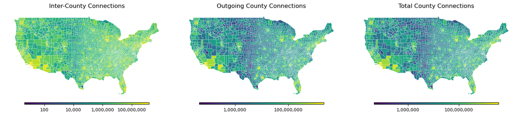

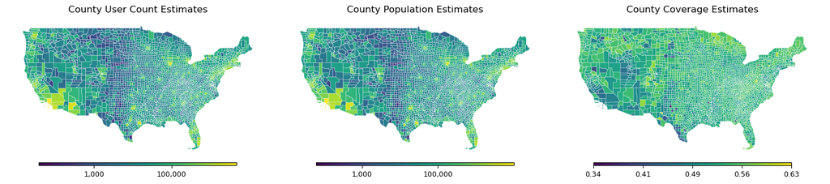

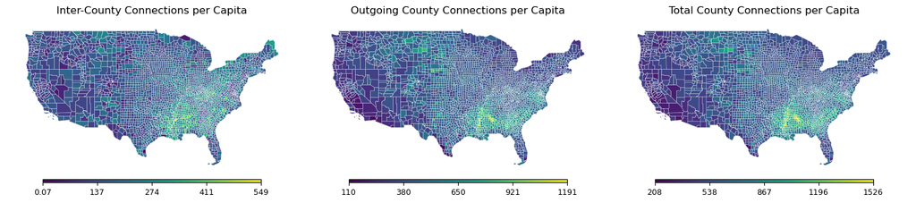

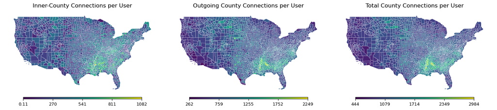

```python
import pandas as pd
import numpy as np
import matplotlib.pyplot as plt
import geopandas as gpd
from matplotlib.ticker import FixedLocator, FixedFormatter
from matplotlib.colors import Normalize

df_inner_county = pd.read_csv('F:\\dsl_CLIMA\\projects\\submittable\\clima\\export\\df_outer_county.csv')
df_cbsa = pd.read_csv('F:\\dsl_CLIMA\\projects\\submittable\\clima\\export\\df_cbsa.csv')
df_msa = pd.read_csv('F:\\dsl_CLIMA\\projects\\submittable\\clima\\export\\df_msa.csv')
df_musa = pd.read_csv('F:\\dsl_CLIMA\\projects\\submittable\\clima\\export\\df_musa.csv')
gdf_county = gpd.read_file('F:\\dsl_CLIMA\\projects\\submittable\\clima\\source\\shape files\\county\\tl_2021_us_county.shp')
gdf_cbsa = gpd.read_file('F:\\dsl_CLIMA\\projects\\submittable\\clima\\source\\shape files\\cbsa\\tl_2021_us_cbsa.shp')

df_inner_county['user_loc'] = df_inner_county['user_loc'].astype(str).str.zfill(5)
df_cbsa['CBSA Code'] = df_cbsa['CBSA Code'].astype(str).str.zfill(5)

gdf_county['user_loc'] = (gdf_county['STATEFP'].str.zfill(2)+ gdf_county['COUNTYFP'].str.zfill(3))
gdf_cbsa.rename(columns={'GEOID': 'CBSA Code'}, inplace=True)
gdf_cbsa['CBSA Code'] = gdf_cbsa['CBSA Code'].astype(str).str.zfill(5)

gdf_county = gdf_county.merge(df_inner_county, on='user_loc', how='left')
gdf_county = gpd.GeoDataFrame(gdf_county, geometry='geometry', crs='EPSG:4326')

gdf_cbsa = gdf_cbsa.merge(df_cbsa, on='CBSA Code', how='left')
gdf_cbsa = gpd.GeoDataFrame(gdf_cbsa, geometry='geometry', crs='EPSG:4326')

def plot_choropleth_per_subplot(
    gdf,
    value_cols,
    titles=None,
    log_scale_cols=None,        # Data log-transform
    force_log_cols=None,        # Force visual log colorbar on linear data
    cmap="viridis",
    missing_color="lightgrey",
    edgecolor="white",
    linewidth=0.2,
    figsize_per_plot=5,
    continental_only=True,
    zoom_padding=0.05,
    cbar_height=0.025,
    cbar_pad=0.012,
    cbar_width_ratio=0.75,      # width ratio of colorbar relative to subplot
    linear_ticks=6,
    log_ticks_per_decade=1
):
    if titles is None:
        titles = value_cols
    if log_scale_cols is None:
        log_scale_cols = []
    if force_log_cols is None:
        force_log_cols = []

    gdf_plot = gdf.copy()

    # ---- Continental US filter ----
    if continental_only:
        continental_fips = [str(i).zfill(2) for i in range(1, 57)
                            if i not in [2, 15, 60, 66, 69, 72, 78]]
        if "STATEFP" in gdf_plot.columns:
            gdf_plot = gdf_plot[gdf_plot["STATEFP"].isin(continental_fips)]
        elif "GEOID" in gdf_plot.columns:
            gdf_plot = gdf_plot[gdf_plot["GEOID"].str[:2].isin(continental_fips)]
        else:
            raise ValueError("Cannot filter continental US: no STATEFP or GEOID column found.")

    n = len(value_cols)
    cols = min(3, n)
    rows = (n + cols - 1) // cols

    fig, axes = plt.subplots(
        rows, cols,
        figsize=(cols * figsize_per_plot, rows * figsize_per_plot),
        constrained_layout=False
    )
    axes = axes.flatten()

    fig.subplots_adjust(
        left=0.02,
        right=0.98,
        top=0.95,
        bottom=0.08,
        hspace=0.10,
        wspace=0.05
    )

    # ---- Zoom bounds with padding ----
    minx, miny, maxx, maxy = gdf_plot.total_bounds
    dx = (maxx - minx) * zoom_padding
    dy = (maxy - miny) * zoom_padding
    bounds = (minx + dx, miny + dy, maxx - dx, maxy - dy)

    for ax, col, title in zip(axes, value_cols, titles):

        data = gdf_plot[col].replace(0, np.nan)
        vmin, vmax = data.min(), data.max()

        # ---- Determine data for plotting ----
        if col in log_scale_cols:
            # log-transform data for plotting
            plot_data = np.where(data > 0, np.log10(data), np.nan)
            norm = Normalize(vmin=np.nanmin(plot_data), vmax=np.nanmax(plot_data))
            is_log = True
        else:
            plot_data = data
            norm = Normalize(vmin=vmin, vmax=vmax)
            is_log = col in force_log_cols  # for colorbar only

        # ---- Plot
        gdf_plot.plot(
            column=plot_data,
            ax=ax,
            cmap=cmap,
            norm=norm,
            missing_kwds={"color": missing_color},
            edgecolor=edgecolor,
            linewidth=linewidth
        )

        ax.set_title(title, fontsize=12)
        ax.set_xlim(bounds[0], bounds[2])
        ax.set_ylim(bounds[1], bounds[3])
        ax.axis("off")

        # ---- Colorbar below subplot ----
        pos = ax.get_position()
        width = pos.width * cbar_width_ratio
        x0 = pos.x0 + (pos.width - width) / 2
        cax = fig.add_axes([x0, pos.y0 - cbar_pad - cbar_height, width, cbar_height])

        # Create colormap for colorbar
        sm = plt.cm.ScalarMappable(cmap=cmap, norm=norm)
        cbar = plt.colorbar(sm, cax=cax, orientation="horizontal")
        cbar.ax.xaxis.get_offset_text().set_visible(False)
        cbar.ax.set_xlabel("")
        cbar.ax.tick_params(labelsize=9)

        # ---- Tick formatting ----
        if col in log_scale_cols:
            # Data is log-transformed, but show original values
            log_ticks = np.logspace(np.floor(np.log10(vmin)),
                                    np.ceil(np.log10(vmax)),
                                    int((np.ceil(np.log10(vmax)) - np.floor(np.log10(vmin))) * log_ticks_per_decade + 1))
            log_ticks = log_ticks[(log_ticks >= vmin) & (log_ticks <= vmax)]
            labels = [f"{int(t):,}" for t in log_ticks]
            cbar.ax.xaxis.set_major_locator(FixedLocator(np.log10(log_ticks)))
            cbar.ax.xaxis.set_major_formatter(FixedFormatter(labels))

        elif col in force_log_cols:
            # Linear data, forced log colorbar
            log_ticks = np.logspace(np.floor(np.log10(vmin)),
                                    np.ceil(np.log10(vmax)),
                                    int((np.ceil(np.log10(vmax)) - np.floor(np.log10(vmin))) * log_ticks_per_decade + 1))
            log_ticks = log_ticks[(log_ticks >= vmin) & (log_ticks <= vmax)]
            # Map ticks to normalized 0-1 for colorbar
            log_norm_ticks = (np.log10(log_ticks) - np.log10(vmin)) / (np.log10(vmax) - np.log10(vmin))
            labels = [f"{int(t):,}" for t in log_ticks]
            cbar.ax.xaxis.set_major_locator(FixedLocator(log_norm_ticks * (cbar.ax.get_xlim()[1] - cbar.ax.get_xlim()[0]) + cbar.ax.get_xlim()[0]))
            cbar.ax.xaxis.set_major_formatter(FixedFormatter(labels))

        else:
            # Linear data
            ticks = np.linspace(vmin, vmax, linear_ticks)
            labels = [f"{t:.2f}" if t < 10 else f"{int(t)}" for t in ticks]
            cbar.ax.xaxis.set_major_locator(FixedLocator(ticks))
            cbar.ax.xaxis.set_major_formatter(FixedFormatter(labels))

    # Hide unused axes
    for ax in axes[n:]:
        ax.axis("off")

    return fig, axes

# --- County Choropleths ---
fig, axes = plot_choropleth_per_subplot(
    gdf=gdf_county,
    value_cols=[
        "inter_county_connections",
        "outer_county_connections",
        "total connections"
    ],
    titles=[
        "Inter-County Connections",
        "Outgoing County Connections",
        "Total County Connections"
    ],
    log_scale_cols=['inter_county_connections', 'outer_county_connections', 'total connections'],
    cmap="viridis",
    continental_only=True,
    zoom_padding=-0.075,
    log_ticks_per_decade=0.5,
    cbar_height=0.01,
    cbar_pad=0.012
)

plt.show()
fig.savefig("F:\\dsl_CLIMA\\projects\\submittable\\clima\\plots\\choropleths\\county_connections_choropleth.png", dpi=800, bbox_inches='tight')

fig, axes = plot_choropleth_per_subplot(
    gdf=gdf_county,
    value_cols=[
        "user_est",
        "pop_est",
        "coverage est"
    ],
    titles=[
        "County User Count Estimates",
        "County Population Estimates",
        "County Coverage Estimates"
    ],
    log_scale_cols=['user_est', 'pop_est'],
    force_log_cols=['user_est','pop_est'],
    cmap="viridis",
    continental_only=True,
    zoom_padding=-0.075,
    log_ticks_per_decade=0.5,
    cbar_height=0.01,
    cbar_pad=0.012,
    linear_ticks=5
)

plt.show()
fig.savefig("F:\\dsl_CLIMA\\projects\\submittable\\clima\\plots\\choropleths\\county_popstats_choropleth.png", dpi=800, bbox_inches='tight')

gdf_county['inter_county_connections per capita'] = gdf_county['inter_county_connections']/gdf_county['pop_est']
gdf_county['inter_county_connections per user'] = gdf_county['inter_county_connections']/gdf_county['user_est']

gdf_county['outer_county_connections per capita'] = gdf_county['outer_county_connections']/gdf_county['pop_est']
gdf_county['outer_county_connections per user'] = gdf_county['outer_county_connections']/gdf_county['user_est']

gdf_county['total connections per capita'] = gdf_county['total connections']/gdf_county['pop_est']
gdf_county['total connections per user'] = gdf_county['total connections']/gdf_county['user_est']


# --- Per User and Per Capita Choropleths ---
fig, axes = plot_choropleth_per_subplot(
    gdf=gdf_county,
    value_cols=[
        "inter_county_connections per capita",
        "outer_county_connections per capita",
        "total connections per capita"
    ],
    titles=[
        "Inter-County Connections per Capita",
        "Outgoing County Connections per Capita",
        "Total County Connections per Capita"
    ],
    cmap="viridis",
    continental_only=True,
    zoom_padding=-0.075,
    log_ticks_per_decade=0.5,
    cbar_height=0.01,
    cbar_pad=0.012,
    linear_ticks=5
)
plt.show()
fig.savefig("F:\\dsl_CLIMA\\projects\\submittable\\clima\\plots\\choropleths\\county_percapita_choropleth.png", dpi=800, bbox_inches='tight')


fig, axes = plot_choropleth_per_subplot(
    gdf=gdf_county,
    value_cols=[
        "inter_county_connections per user",
        "outer_county_connections per user",
        "total connections per user"
    ],
    titles=[
        "Inner-County Connections per User",
        "Outgoing County Connections per User",
        "Total County Connections per User"
    ],
    cmap="viridis",
    continental_only=True,
    zoom_padding=-0.075,
    log_ticks_per_decade=0.5,
    cbar_height=0.01,
    cbar_pad=0.012,
    linear_ticks=5
)
plt.show()
fig.savefig("F:\\dsl_CLIMA\\projects\\submittable\\clima\\plots\\choropleths\\county_peruser_choropleth.png", dpi=800, bbox_inches='tight')
```

## Demographics Plots:

The demographics section zooms from the national scaling picture down to a handful of NYC census blocks — specifically, the Hamilton Beach and Howard Beach blocks in Queens (FIPS prefix `360810884006`), which are the focus communities for CLIMA's coastal-flood-risk interviews, with Red Hook (Brooklyn) included later as a comparison.

For each block (and the aggregate across all selected blocks), we generate:

- **Age/Sex population pyramids** with the NYC census-block average overlaid as dots, so each block can be read against the citywide baseline.
- **Race/Ethnicity distributions** (White non-Hispanic, Black non-Hispanic, Asian non-Hispanic, Hispanic of any race), again with citywide averages overlaid.
- **Household size distributions** (1-person through 5+-person, with 5+, 6, 7+ collapsed for readability).
- **Housing occupancy** (occupied vs. vacant).
- **Housing tenure** (owner- vs. renter-occupied) — the most policy-relevant variable for the homeowner-mobility framing of CLIMA.

The data source for everything in this cell is the 2020 Decennial Census DHC files at the block level (H3, H4, H9, P3, P5, P12).

```python
import pandas as pd
import numpy as np
import matplotlib.pyplot as plt

df_tenure = pd.read_csv('F:\\dsl_CLIMA\\projects\\submittable\\clima\\source\\census demographic files\\DECENNIALDHC2020.H4-Data.csv', dtype={'GEO_ID':str, 'NAME':str})
df_household_size = pd.read_csv('F:\\dsl_CLIMA\\projects\\submittable\\clima\\source\\census demographic files\\DECENNIALDHC2020.H9-Data.csv', dtype={'GEO_ID':str, 'NAME':str})
df_sex_by_age = pd.read_csv('F:\\dsl_CLIMA\\projects\\submittable\\clima\\source\\census demographic files\\DECENNIALDHC2020.P12-Data.csv', dtype={'GEO_ID':str, 'NAME':str})
df_race = pd.read_csv('F:\\dsl_CLIMA\\projects\\submittable\\clima\\source\\census demographic files\\DECENNIALDHC2020.P3-Data.csv', dtype={'GEO_ID':str, 'NAME':str})
df_hispanic = pd.read_csv('F:\\dsl_CLIMA\\projects\\submittable\\clima\\source\\census demographic files\\DECENNIALDHC2020.P5-Data.csv', dtype={'GEO_ID':str, 'NAME':str})
df_occupancy = pd.read_csv('F:\\dsl_CLIMA\\projects\\submittable\\clima\\source\\census demographic files\\DECENNIALDHC2020.H3-Data.csv', dtype={'GEO_ID':str, 'NAME':str})

df_household_size = df_household_size.drop(columns=['NAME'])
df_sex_by_age = df_sex_by_age.drop(columns=['NAME'])
df_race = df_race.drop(columns=['NAME'])
df_hispanic = df_hispanic.drop(columns=['NAME'])
df_occupancy = df_occupancy.drop(columns=['NAME'])
df_merged = df_tenure.merge(df_household_size, on='GEO_ID', how='outer').astype(str) \
               .merge(df_sex_by_age, on='GEO_ID', how='outer').astype(str) \
               .merge(df_race, on='GEO_ID', how='outer').astype(str) \
               .merge(df_hispanic, on='GEO_ID', how='outer').astype(str) \
               .merge(df_occupancy, on='GEO_ID', how='outer').astype(str)
df_merged = df_merged.drop(columns=['Unnamed: 6', 'Unnamed: 10_x', 'Unnamed: 51', 'Unnamed: 10_y', 'Unnamed: 19', 'Unnamed: 5'])

target_locations = ['1000000US360810884006000', '1000000US360810884006001', '1000000US360810884006003', '1000000US360810884006005', '1000000US360810884006004', '1000000US360810884006006', '1000000US360810884006008', '1000000US360810884006009', '1000000US360810884006010']

df_filtered = df_merged.copy()
df_filtered = df_filtered[df_filtered['GEO_ID'].isin(target_locations)]

df_filtered.columns = df_filtered.columns.str.strip()
df_merged.columns = df_merged.columns.str.strip()

def plot_population_pyramid(df_subset, df_all):
    male_cols = [f'P12_{i:03}N' for i in range(3, 26)]
    female_cols = [f'P12_{i:03}N' for i in range(27, 50)]

    age_labels = [
        'Under 5', '5-9', '10-14', '15-17', '18-19', '20', '21', '22-24',
        '25-29', '30-34', '35-39', '40-44', '45-49', '50-54', '55-59',
        '60-61', '62-64', '65-66', '67-69', '70-74', '75-79', '80-84', '85+'
    ]
    y = np.arange(len(age_labels))

    # Convert numeric columns
    cols_to_convert = male_cols + female_cols + ['P12_001N']
    df_all[cols_to_convert] = df_all[cols_to_convert].apply(pd.to_numeric, errors='coerce').fillna(0)
    df_subset[cols_to_convert] = df_subset[cols_to_convert].apply(pd.to_numeric, errors='coerce').fillna(0)

    male_totals = df_subset[male_cols].sum()
    female_totals = df_subset[female_cols].sum()
    total_subset = male_totals.sum() + female_totals.sum()
    male_percent = (male_totals / total_subset) * 100
    female_percent = (female_totals / total_subset) * 100

    df_nonzero = df_all[df_all['P12_001N'] > 0].copy()
    total_all = df_nonzero[male_cols + female_cols].sum().sum()
    male_avg = df_nonzero[male_cols].sum() / total_all * 100
    female_avg = df_nonzero[female_cols].sum() / total_all * 100

    max_male = max(male_percent.max(), male_avg.max()) * 1.1
    max_female = max(female_percent.max(), female_avg.max()) * 1.1

    fig, ax = plt.subplots(figsize=(14, 9))

    # Plot age labels temporarily to measure their width
    txts = []
    for i, label in enumerate(age_labels):
        txt = ax.text(0, i, label, ha='center', va='center', fontsize=16, fontweight='bold',
                      bbox=dict(facecolor='white', edgecolor='none', alpha=0.9))
        txts.append(txt)

    fig.canvas.draw()
    renderer = fig.canvas.get_renderer()

    # Calculate max label width in data coordinates
    label_widths = []
    for txt in txts:
        bbox = txt.get_window_extent(renderer=renderer)
        inv = ax.transData.inverted()
        left_data = inv.transform((bbox.x0, 0))[0]
        right_data = inv.transform((bbox.x1, 0))[0]
        width_data = right_data - left_data
        label_widths.append(width_data)

    max_label_width = max(label_widths)
    center_padding = max_label_width + 0.5  # add margin for padding

    # Clear axis to re-plot bars and labels properly
    ax.cla()

    # Plot male bars starting at -center_padding, widths negative to grow left
    ax.barh(y, -male_percent.values, color='steelblue', alpha=0.7, label='Percent Male',
            left=-center_padding)

    # Plot female bars starting at center_padding, widths positive to grow right
    ax.barh(y, female_percent.values, color='lightcoral', alpha=0.7, label='Percent Female',
            left=center_padding)

    # Plot average dots shifted similarly
    ax.plot(-male_avg.values - center_padding, y, 'o', color='navy', label='NYC Census Block Avg Male')
    ax.plot(female_avg.values + center_padding, y, 'o', color='darkred', label='NYC Census Block Avg Female')

    # Plot age labels centered at zero with white background
    for i, label in enumerate(age_labels):
        ax.text(0, i, label, ha='center', va='center', fontsize=16, fontweight='bold',
                bbox=dict(facecolor='white', edgecolor='none', alpha=0.9))

    # Vertical black lines at true zero baselines for both sides
    ax.vlines(-center_padding, ymin=-1, ymax=len(age_labels), colors='black', linewidth=1.5)
    ax.vlines(center_padding, ymin=-1, ymax=len(age_labels), colors='black', linewidth=1.5)

    # Set axis limits with padding
    ax.set_xlim(-max_male - center_padding * 2, max_female + center_padding * 2)
    ax.set_ylim(-1, len(age_labels))
```

```python
    # X-axis ticks mirrored and adjusted for padding
    left_ticks = np.linspace(0, max_male, 6)
    right_ticks = np.linspace(0, max_female, 6)
    ticks_left = -left_ticks - center_padding
    ticks_right = right_ticks + center_padding
    all_ticks = np.concatenate((ticks_left[::-1], [0], ticks_right))
    ax.set_xticks(all_ticks)

    # Tick labels: absolute percentage values without label at center zero
    tick_labels = [f"{int(abs(x + center_padding))}%" if x < 0 else "" for x in ticks_left[::-1]]
    tick_labels += [""]
    tick_labels += [f"{int(x - center_padding)}%" if x > 0 else "" for x in ticks_right]
    ax.set_xticklabels(tick_labels)

    # X-axis at bottom
    ax.set_xlabel("Percentage of Total Population (%)", fontsize=16)
    ax.xaxis.set_ticks_position('bottom')
    ax.xaxis.set_label_position('bottom')

    # Hide y-axis ticks
    ax.set_yticks([])

    # Vertical center line separating male/female sides
    ax.axvline(0, color='black', linewidth=1)

    # Side headers above bars
    ax.text(-max_male  - center_padding, len(age_labels) + 0.5, "Male", ha='center',
            fontsize=12, fontweight='bold', color='steelblue')
    ax.text(max_female  + center_padding, len(age_labels) + 0.5, "Female", ha='center',
            fontsize=12, fontweight='bold', color='darkred')

    # Title and legend
    ax.set_title("Age/Sex Population Distribution for Hamilton Beach Census Blocks", fontsize=16, fontweight='bold')
    ax.legend(loc='upper right')

    plt.tight_layout()
    plt.show()
    fig.savefig("F:\\dsl_CLIMA\\projects\\submittable\\clima\\plots\\demographics\\bar charts\\allBlocks\\hb_allBlocks_popPyramid.png", dpi=800, bbox_inches='tight')
plot_population_pyramid(df_filtered, df_merged)

def plot_population_pyramid_by_block(df_subset, df_all):

    male_cols = [f'P12_{i:03}N' for i in range(3, 26)]
    female_cols = [f'P12_{i:03}N' for i in range(27, 50)]

    age_labels = [
        'Under 5', '5-9', '10-14', '15-17', '18-19', '20', '21', '22-24',
        '25-29', '30-34', '35-39', '40-44', '45-49', '50-54', '55-59',
        '60-61', '62-64', '65-66', '67-69', '70-74', '75-79', '80-84', '85+'
    ]
    y = np.arange(len(age_labels))

    label_fontsize = 16
    center_pad = 2

    # Clean numeric data
    cols_to_convert = male_cols + female_cols + ['P12_001N']
    df_all[cols_to_convert] = df_all[cols_to_convert].apply(pd.to_numeric, errors='coerce').fillna(0)
    df_subset[cols_to_convert] = df_subset[cols_to_convert].apply(pd.to_numeric, errors='coerce').fillna(0)

    for idx, row in df_subset.iterrows():
        male_counts = row[male_cols]
        female_counts = row[female_cols]
        total_population = male_counts.sum() + female_counts.sum()
        if total_population == 0:
            print(f"Skipping block {idx} with zero population")
            continue

        # Compute block percentages
        male_percent = (male_counts / total_population) * 100
        female_percent = (female_counts / total_population) * 100

        # NYC average
        df_nonzero = df_all[df_all['P12_001N'] > 0]
        total_all = df_nonzero[male_cols + female_cols].sum().sum()
        male_avg = df_nonzero[male_cols].sum() / total_all * 100
        female_avg = df_nonzero[female_cols].sum() / total_all * 100

        # Max for symmetrical scaling
        max_pct = max(male_percent.max(), female_percent.max(), male_avg.max(), female_avg.max())
        max_pct = np.ceil(max_pct / 5.0) * 5  # Round up to nearest 5%

        fig, ax = plt.subplots(figsize=(14, 9))

        # Draw vertical bars at zero lines
        ax.axvline(-center_pad, color='black', linewidth=2.5, zorder=5)
        ax.axvline(center_pad, color='black', linewidth=2.5, zorder=5)

        # Male bars
        ax.barh(y, -male_percent.values, left=-center_pad,
                color='steelblue', alpha=0.7, label='Percent Male', zorder=3)

        # Female bars
        ax.barh(y, female_percent.values, left=center_pad,
                color='lightcoral', alpha=0.7, label='Percent Female', zorder=3)

        # Average markers
        ax.plot(-male_avg.values - center_pad, y, 'o', color='navy', label='NYC Avg Male', zorder=4)
        ax.plot(female_avg.values + center_pad, y, 'o', color='darkred', label='NYC Avg Female', zorder=4)

        # Age group labels centered between sides
        for i, label in enumerate(age_labels):
            ax.text(0, i, label, ha='center', va='center', fontsize=label_fontsize,
                    fontweight='bold', bbox=dict(facecolor='white', edgecolor='none', alpha=0.9), zorder=2)

        # Gender labels at top of each side
        ax.text(-center_pad - max_pct, len(age_labels) + 0.8, "Male",
                ha='center', fontsize=label_fontsize + 2, fontweight='bold', color='steelblue')
        ax.text(center_pad + max_pct, len(age_labels) + 0.8, "Female",
                ha='center', fontsize=label_fontsize + 2, fontweight='bold', color='darkred')

        # Axis limits
        ax.set_xlim(-center_pad - max_pct, center_pad + max_pct)
        ax.set_ylim(-1, len(age_labels))
        ax.set_yticks([])

        # Symmetrical ticks
        tick_vals = np.linspace(0, max_pct, 6)
        ticks_left = -tick_vals - center_pad
        ticks_right = tick_vals + center_pad
        ax.set_xticks(np.concatenate((ticks_left[::-1], [0], ticks_right)))
        ax.set_xticklabels(
            [f"{int(t)}%" for t in tick_vals[::-1]] + [""] + [f"{int(t)}%" for t in tick_vals],
            fontsize=label_fontsize
        )

        ax.set_xlabel("Percentage of Total Population (%)", fontsize=label_fontsize + 2)
        ax.xaxis.set_ticks_position('bottom')
        ax.xaxis.set_label_position('bottom')

        # Block code from GEO_ID
        block_code = str(row['GEO_ID'])[-4:]
        ax.set_title(f"Age/Sex Population Distribution for Block {block_code}",
                     fontsize=label_fontsize + 4, fontweight='bold')

        ax.legend(loc='upper right', fontsize=label_fontsize)
        plt.tight_layout()
        plt.show()
        fig.savefig(f"F:\\dsl_CLIMA\\projects\\submittable\\clima\\plots\\demographics\\bar charts\\population pyramid\\hb_{block_code}_popPyramid.png", dpi=800, bbox_inches='tight')
```

```python
plot_population_pyramid_by_block(df_filtered, df_merged)


def plot_race_distribution_by_block(df_subset, df_all):

    # Define relevant columns
    race_cols = {
        "White alone, Non-Hispanic": "P5_003N",
        "Black or African American alone, Non-Hispanic": "P5_004N",
        "Asian alone, Non-Hispanic": "P5_006N",
    }
    hispanic_cols = [f'P5_{i:03}N' for i in range(11, 18)]
    all_cols = list(race_cols.values()) + hispanic_cols + ['P5_001N']

    # Clean and convert to numeric
    df_subset[all_cols] = df_subset[all_cols].apply(pd.to_numeric, errors='coerce').fillna(0)
    df_all[all_cols] = df_all[all_cols].apply(pd.to_numeric, errors='coerce').fillna(0)

    # NYC-wide totals and average percentages
    total_all_pop = df_all["P5_001N"].sum()
    race_vals_all = {label: df_all[col].sum() for label, col in race_cols.items()}
    race_vals_all["Hispanic or Latino (All)"] = df_all[hispanic_cols].sum().sum()
    avg_pct = {k: (v / total_all_pop) * 100 for k, v in race_vals_all.items()}

    # Sort categories by NYC-wide percentage descending
    sorted_items = sorted(avg_pct.items(), key=lambda x: x[1], reverse=True)
    categories = [k for k, _ in sorted_items]

    ### First plot: combined total of df_subset
    subset_total = df_subset[race_cols.values()].sum()
    subset_hispanic_total = df_subset[hispanic_cols].sum().sum()
    subset_pop_total = df_subset["P5_001N"].sum()

    if subset_pop_total > 0:
        combined_vals = {
            label: subset_total[race_cols[label]] for label in race_cols
        }
        combined_vals["Hispanic or Latino (All)"] = subset_hispanic_total
        combined_pct = {k: (v / subset_pop_total) * 100 for k, v in combined_vals.items()}

        print(f"\n--- Combined Race/Ethnicity Distribution for Hamilton/Howard Beach Census Blocks ---")
        for label in categories:
            count = int(combined_vals[label])
            print(f"  {label}: {count}")
        print(f"Total population: {int(subset_pop_total)}")

        values = [combined_pct[k] for k in categories]
        averages = [avg_pct[k] for k in categories]
        y = np.arange(len(categories))

        fig, ax = plt.subplots(figsize=(16, 6))
        ax.barh(y, values, color='steelblue', alpha=0.85, label='Hamilton/Howard Beach Census Blocks Combined')
        ax.plot(averages, y, 'ko', label='NYC Census Block Avg')

        ax.set_yticks(y)
        ax.set_yticklabels(categories, fontsize=16)
        ax.invert_yaxis()
        ax.set_xlabel('Percentage of Total Population (%)', fontsize=20)
        ax.tick_params(axis='x', labelsize=16)
        ax.set_title('Race/Ethnicity Distribution (Hamilton/Howard Beach Census Blocks)', fontsize=20, fontweight='bold')
        ax.legend(loc='lower right', fontsize=14)

        plt.tight_layout()
        plt.show()
        fig.savefig(f"F:\\dsl_CLIMA\\projects\\submittable\\clima\\plots\\demographics\\bar charts\\allBlocks\\hb_allBlocks_raceDistribution.png", dpi=800, bbox_inches='tight')


    ### Plot individual blocks
    for idx, row in df_subset.iterrows():
        geo_id = str(row.get('GEO_ID', f'{idx}'))
        block_name = geo_id[-4:]
        total_pop = row["P5_001N"]
        if total_pop == 0:
            print(f"Skipping {block_name} due to zero population.")
            continue

        race_vals = {label: row[race_cols[label]] for label in race_cols}
        race_vals["Hispanic or Latino (All)"] = row[hispanic_cols].sum()
        race_pct = {k: (v / total_pop) * 100 for k, v in race_vals.items()}

        print(f"\n--- Race/Ethnicity Distribution for {block_name} ---")
        for label in categories:
            count = int(race_vals[label])
            print(f"  {label}: {count}")
        print(f"Total population: {int(total_pop)}")

        values = [race_pct[k] for k in categories]
        averages = [avg_pct[k] for k in categories]
        y = np.arange(len(categories))

        fig, ax = plt.subplots(figsize=(16, 6))
        ax.barh(y, values, color='steelblue', alpha=0.85, label=block_name)
        ax.plot(averages, y, 'ko', label='NYC Census Block Avg')

        ax.set_yticks(y)
        ax.set_yticklabels(categories, fontsize=16)
        ax.invert_yaxis()
        ax.set_xlabel('Percentage of Total Population', fontsize=20)
        ax.tick_params(axis='x', labelsize=16)
        ax.set_title(f'Race/Ethnicity Distribution for {block_name}', fontsize=20, fontweight='bold')
        ax.legend(loc='lower right', fontsize=14)

        plt.tight_layout()
        plt.show()
        fig.savefig(f"F:\\dsl_CLIMA\\projects\\submittable\\clima\\plots\\demographics\\bar charts\\race distribution\\hb_{block_name}_raceDistribution.png", dpi=800, bbox_inches='tight')


plot_race_distribution_by_block(df_filtered, df_merged)

def plot_household_size_distribution(df_subset, df_all):
    # Original size columns (including 6- and 7+)
    original_cols = [f'H9_{i:03}N' for i in range(2, 9)]
    total_col = 'H9_001N'
    cols_to_convert = original_cols + [total_col]

    # Convert all to numeric
    df_all[cols_to_convert] = df_all[cols_to_convert].apply(pd.to_numeric, errors='coerce').fillna(0)
    df_subset[cols_to_convert] = df_subset[cols_to_convert].apply(pd.to_numeric, errors='coerce').fillna(0)

    # Combine 5-or-more-person households
    for df in [df_all, df_subset]:
        df['H9_006N'] = df[['H9_006N', 'H9_007N', 'H9_008N']].sum(axis=1)

    size_cols = [f'H9_{i:03}N' for i in range(2, 7)]  # Now includes aggregated 5+
    labels = [
        '1-person household',
        '2-person household',
        '3-person household',
        '4-person household',
        '5-or-more-person household'
    ]

    # NYC-wide averages
    total_all = df_all[total_col].sum()
    all_counts = df_all[size_cols].sum()
    pct_all = (all_counts / total_all * 100).values

    # Aggregate for df_subset
    subset_total = df_subset[total_col].sum()
    subset_counts = df_subset[size_cols].sum()
    subset_pct = (subset_counts / subset_total * 100).values
```

```python
    # Plot total for subset
    fig, ax = plt.subplots(figsize=(10, 6))
    ax.barh(labels, subset_pct, color='seagreen', label='Hamilton/Howard Beach Census Blocks Total')
    ax.plot(pct_all, labels, 'ko', label='NYC Census Block Avg')

    ax.set_xlabel('Percentage of Households', fontsize=12)
    ax.set_title('Household Size Distribution (1–5+ persons)\nHamilton/Howard Beach Census Blocks', fontsize=14, fontweight='bold')
    ax.invert_yaxis()
    ax.legend()
    plt.tight_layout()
    plt.show()
    fig.savefig(f"F:\\dsl_CLIMA\\projects\\submittable\\clima\\plots\\demographics\\bar charts\\allBlocks\\hb_allBlocks_householdsizeDistribution.png", dpi=800, bbox_inches='tight')

    # Plot individual blocks
    for _, row in df_subset.iterrows():
        geo_id = str(row['GEO_ID'])
        block_id = geo_id[-4:]
        block_counts = row[size_cols].astype(float)
        total = row[total_col]

        if total == 0:
            continue

        pct = (block_counts / total * 100).values

        fig, ax = plt.subplots(figsize=(10, 6))
        ax.barh(labels, pct, color='mediumseagreen', label=f'Block {block_id}')
        ax.plot(pct_all, labels, 'ko', label='NYC Census Block Avg')

        ax.set_xlabel('Percentage of Households', fontsize=12)
        ax.set_title(f'Household Size Distribution (1–5+ persons)\nBlock {block_id}', fontsize=14, fontweight='bold')
        ax.invert_yaxis()
        ax.legend()
        plt.tight_layout()
        plt.show()
    fig.savefig(f"F:\\dsl_CLIMA\\projects\\submittable\\clima\\plots\\demographics\\bar charts\\race distribution\\hb_{block_id}_householdsizeDistribution.png", dpi=800, bbox_inches='tight')

plot_household_size_distribution(df_filtered, df_merged)

def plot_occupancy_distribution(df_subset, df_all):

    # Column references and labels
    total_col = 'H3_001N'
    tenure_cols = ['H3_002N', 'H3_003N']
    labels = ['Occupied', 'Vacant']

    df_subset[[total_col] + tenure_cols] = df_subset[[total_col] + tenure_cols].apply(pd.to_numeric, errors='coerce').fillna(0)
    df_all[[total_col] + tenure_cols] = df_all[[total_col] + tenure_cols].apply(pd.to_numeric, errors='coerce').fillna(0)

    # NYC-wide totals and average percentages
    total_all = df_all[total_col].sum()
    tenure_total_all = df_all[tenure_cols].sum()
    avg_pct = (tenure_total_all / total_all * 100).values

    # Plot aggregate for all blocks in df_subset
    total_subset = df_subset[total_col].sum()
    if total_subset > 0:
        tenure_subset_sum = df_subset[tenure_cols].sum()
        subset_pct = (tenure_subset_sum / total_subset * 100).values

        fig, ax = plt.subplots(figsize=(8, 4))
        y = np.arange(len(labels))

        ax.barh(y, subset_pct, color='seagreen', edgecolor='black', label='Hamilton/Howard Beach Census Blocks Total')
        ax.plot(avg_pct, y, 'ko', label='NYC Census Block Avg')

        ax.set_yticks(y)
        ax.set_yticklabels(labels, fontsize=11)
        ax.set_xlabel('Percentage of Housing Units', fontsize=12)
        ax.set_title('Housing Occupancy Distribution\nHamilton/Howard Beach Census Blocks', fontsize=14, fontweight='bold')
        ax.invert_yaxis()
        ax.legend()
        plt.tight_layout()
        plt.show()
        fig.savefig(f"F:\\dsl_CLIMA\\projects\\submittable\\clima\\plots\\demographics\\bar charts\\allBlocks\\hb_allBlocks_occupancyDistribution.png", dpi=800, bbox_inches='tight')


    # 2. Plot each individual census block
    for _, row in df_subset.iterrows():
        total = row[total_col]
        if total == 0:
            continue

        geo_id = str(row['GEO_ID'])
        block_id = geo_id[-4:]
        values = row[tenure_cols].values.astype(float)
        pct = (values / total * 100)

        fig, ax = plt.subplots(figsize=(8, 4))
        y = np.arange(len(labels))

        ax.barh(y, pct, color='cornflowerblue', edgecolor='black', label=f'Block {block_id}')
        ax.plot(avg_pct, y, 'ko', label='NYC Census Block Avg')

        ax.set_yticks(y)
        ax.set_yticklabels(labels, fontsize=11)
        ax.set_xlabel('Percentage of Housing Units', fontsize=12)
        ax.set_title(f'Housing Occupancy Distribution\nBlock {block_id}', fontsize=14, fontweight='bold')
        ax.invert_yaxis()
        ax.legend()
        plt.tight_layout()
        plt.show()
        fig.savefig(f"F:\\dsl_CLIMA\\projects\\submittable\\clima\\plots\\demographics\\bar charts\\occupancy\\hb_{block_id}_occupancyDistribution.png", dpi=800, bbox_inches='tight')


plot_occupancy_distribution(df_filtered, df_merged)

def plot_housing_tenure_distribution(df_subset, df_all):

    # Column references
    total_col = 'H4_001N'
    owner_cols = ['H4_002N', 'H4_003N']
    renter_col = 'H4_004N'
    tenure_cols = owner_cols + [renter_col]
    labels = ['Owner-occupied', 'Renter-occupied']

    df_subset[[total_col] + tenure_cols] = df_subset[[total_col] + tenure_cols].apply(pd.to_numeric, errors='coerce').fillna(0)
    df_all[[total_col] + tenure_cols] = df_all[[total_col] + tenure_cols].apply(pd.to_numeric, errors='coerce').fillna(0)

    # Aggregate totals for NYC
    owner_total_all = df_all[owner_cols].sum().sum()
    renter_total_all = df_all[renter_col].sum()
    total_all = df_all[total_col].sum()
    avg_pct = np.array([owner_total_all, renter_total_all]) / total_all * 100  # NYC averages

    # 1. Combined summary for all target blocks
    owner_total_subset = df_subset[owner_cols].sum().sum()
    renter_total_subset = df_subset[renter_col].sum()
    total_subset = df_subset[total_col].sum()

    print(f"--- Combined Housing Tenure for Selected Census Blocks ---")
    print(f"  Owner-occupied: {int(owner_total_subset)}")
    print(f"  Renter-occupied: {int(renter_total_subset)}")
    print(f"Total housing units: {int(total_subset)}\n")

    # Percentages for plotting
    if total_subset > 0:
        subset_pct = np.array([owner_total_subset, renter_total_subset]) / total_subset * 100

        fig, ax = plt.subplots(figsize=(8, 4))
        y = np.arange(len(labels))
```

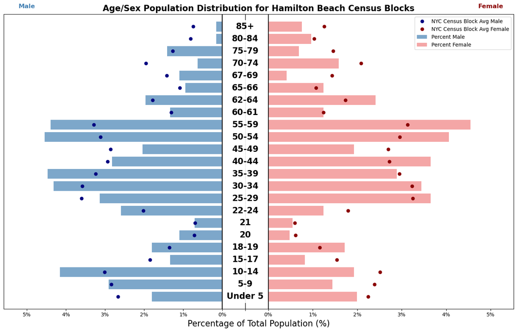

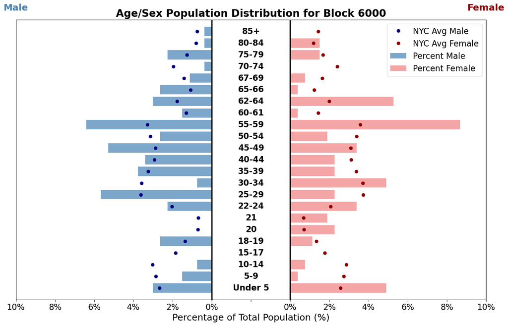

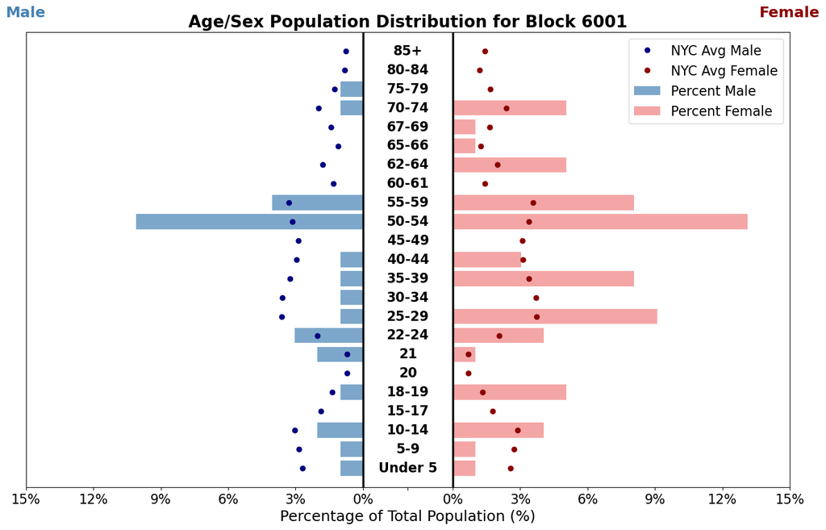

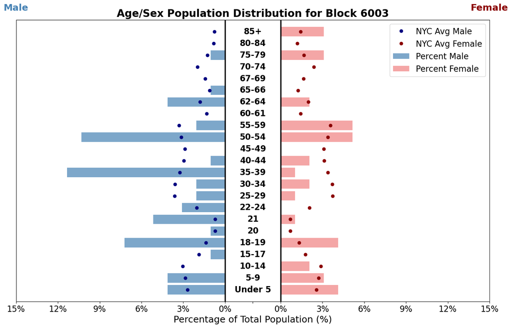

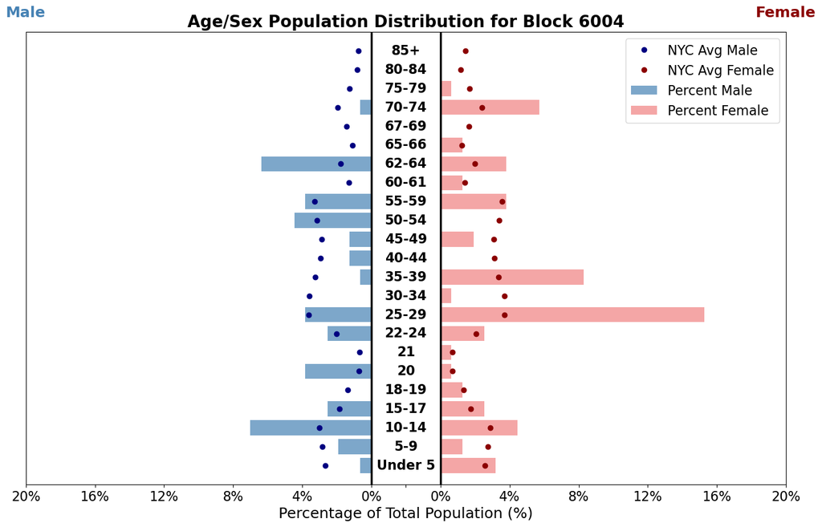

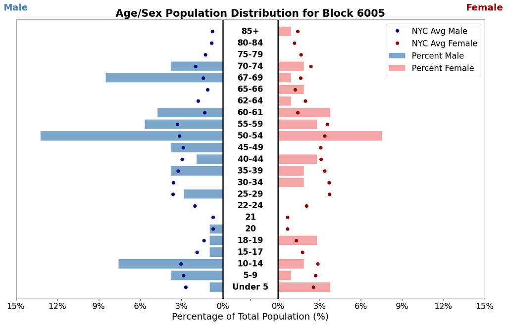

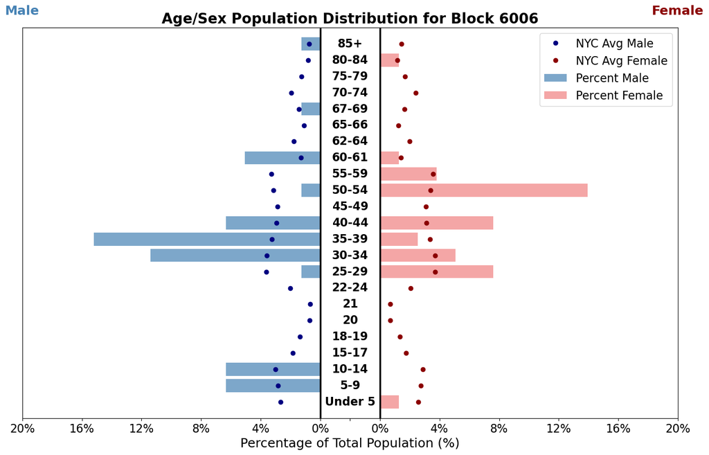

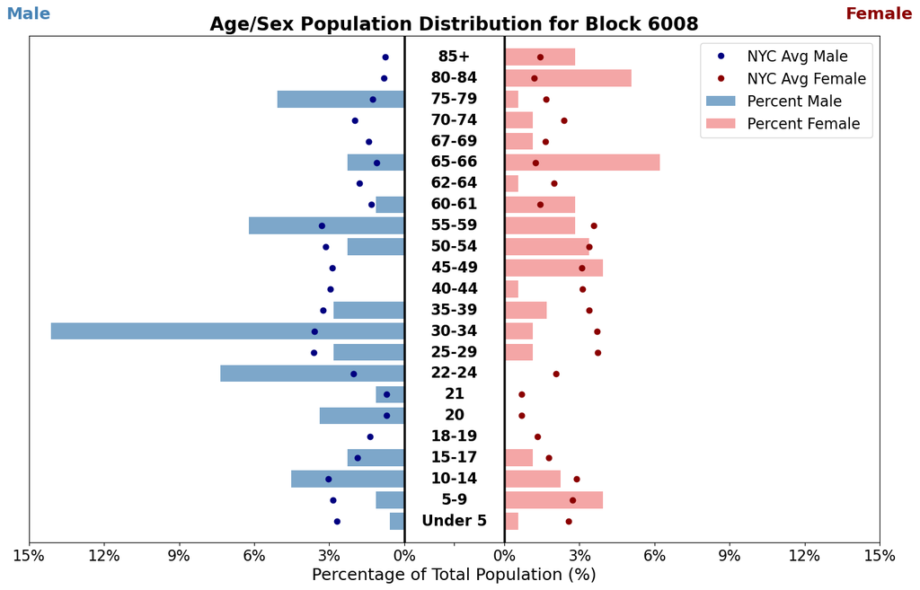

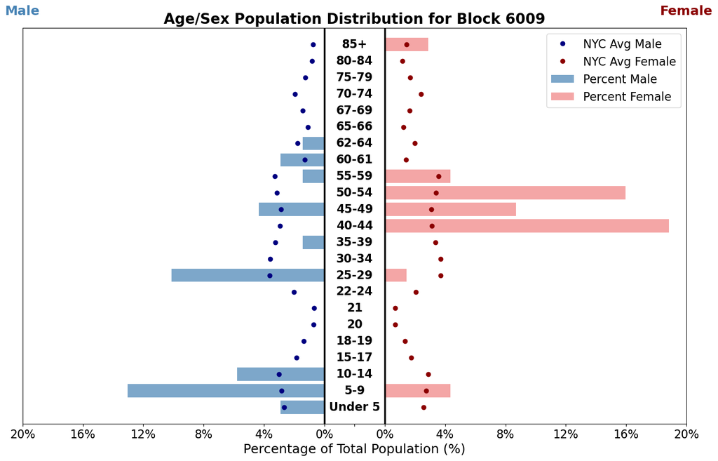

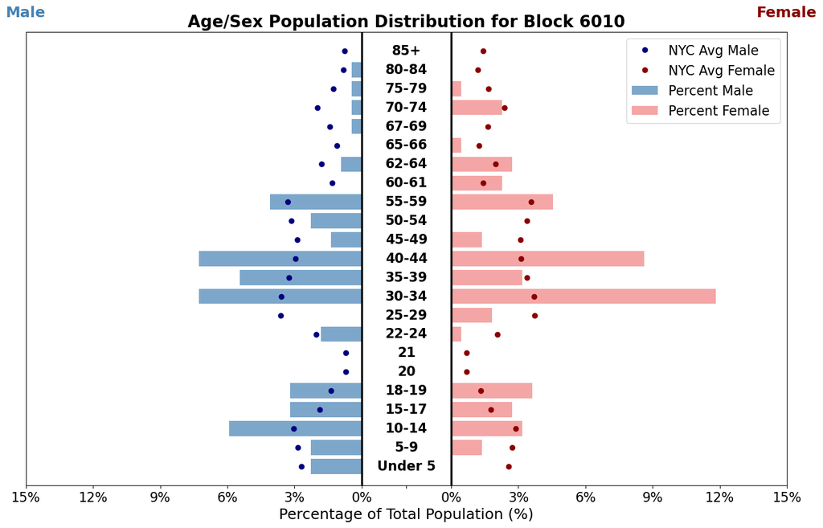

```
--- Combined Race/Ethnicity Distribution for Hamilton/Howard Beach Census Blocks ---
  White alone, Non-Hispanic: 598
  Hispanic or Latino (All): 436
  Black or African American alone, Non-Hispanic: 80
  Asian alone, Non-Hispanic: 110
Total population: 1269
```

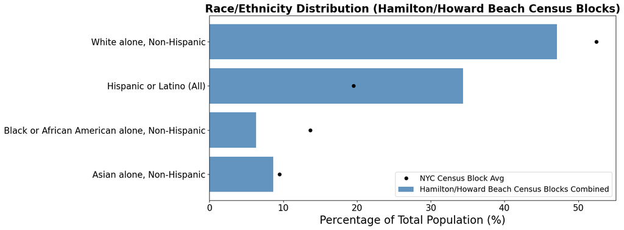

```
--- Race/Ethnicity Distribution for 6000 ---
  White alone, Non-Hispanic: 145
  Hispanic or Latino (All): 86
  Black or African American alone, Non-Hispanic: 6
  Asian alone, Non-Hispanic: 12
Total population: 265
```

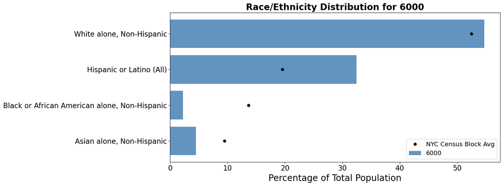

```
--- Race/Ethnicity Distribution for 6001 ---
  White alone, Non-Hispanic: 52
  Hispanic or Latino (All): 27
  Black or African American alone, Non-Hispanic: 6
  Asian alone, Non-Hispanic: 11
Total population: 99
```

[38 more figures not shown]

```python
        ax.barh(y, subset_pct, color='seagreen', edgecolor='black', label='Selected Blocks Total')
        ax.plot(avg_pct, y, 'ko', label='NYC Census Block Avg')

        ax.set_yticks(y)
        ax.set_yticklabels(labels, fontsize=11)
        ax.set_xlabel('Percentage of Housing Units', fontsize=12)
        ax.set_title('Housing Tenure Distribution\nSelected NYC Census Blocks', fontsize=14, fontweight='bold')
        ax.invert_yaxis()
        ax.legend()
        plt.tight_layout()
        plt.show()
        fig.savefig(f"F:\\dsl_CLIMA\\projects\\submittable\\clima\\plots\\demographics\\bar charts\\allBlocks\\hb_allBlocks_housingtenureDistribution.png", dpi=800, bbox_inches='tight')

    # Plot each individual census block
    for _, row in df_subset.iterrows():
        total = row[total_col]
        if total == 0:
            continue

        geo_id = str(row['GEO_ID'])
        block_id = geo_id[-4:]
        owner_count = row[owner_cols].sum()
        renter_count = row[renter_col]
        pct = np.array([owner_count, renter_count]) / total * 100

        print(f"--- Housing Tenure for {block_id} ---")
        print(f"  Owner-occupied: {int(owner_count)}")
        print(f"  Renter-occupied: {int(renter_count)}")
        print(f"Total housing units: {int(total)}\n")

        fig, ax = plt.subplots(figsize=(8, 4))
        y = np.arange(len(labels))

        ax.barh(y, pct, color='cornflowerblue', edgecolor='black', label=f'Block {block_id}')
        ax.plot(avg_pct, y, 'ko', label='NYC Census Block Avg')

        ax.set_yticks(y)
        ax.set_yticklabels(labels, fontsize=11)
        ax.set_xlabel('Percentage of Housing Units', fontsize=12)
        ax.set_title(f'Housing Tenure Distribution\nBlock {block_id}', fontsize=14, fontweight='bold')
        ax.invert_yaxis()
        ax.legend()
        plt.tight_layout()
        plt.show()
        fig.savefig(f"F:\\dsl_CLIMA\\projects\\submittable\\clima\\plots\\demographics\\bar charts\\tenure\\hb_{block_id}_housingtenureDistribution.png", dpi=800, bbox_inches='tight')

plot_housing_tenure_distribution(df_filtered, df_merged)
```

## Pie Charts of Educational & Household Income Levels:

A side-by-side look at **educational attainment** and **household income** for Hamilton Beach (Queens, green palette) and Red Hook (Brooklyn, blue palette). Both communities sit in FEMA-designated coastal flood zones, but they differ markedly in socioeconomic composition — Hamilton Beach skews toward homeowner-occupied middle-income households, Red Hook toward a more income-bimodal renter population — and the pie charts make that contrast immediately visible.

The underlying data is IPUMS NHGIS `nhgis0004_ds267_20235` (ACS 5-year, block-group resolution). Education categories are collapsed from the 24 ACS bins into 9 readable buckets (No HS / Only HS / GED / Incomplete College / Associate / Bachelor / Master / Professional / Doctorate); income from 16 ACS bins into 9 buckets (`<$10k` through `$200k+`).

```
C:\Users\Ayush Sarkar\AppData\Local\Temp\ipykernel_26324\1905657506.py:105: MatplotlibDeprecationWarning: The get_cmap function was deprecated in Matplotlib 3.7 and will be removed in 3.11. Use ``matplotlib.colormaps[name]`` or ``matplotlib.colormaps.get_cmap()`` or ``pyplot.get_cmap()`` instead.
  cmap = cm.get_cmap(palette, len(logical_order))
```

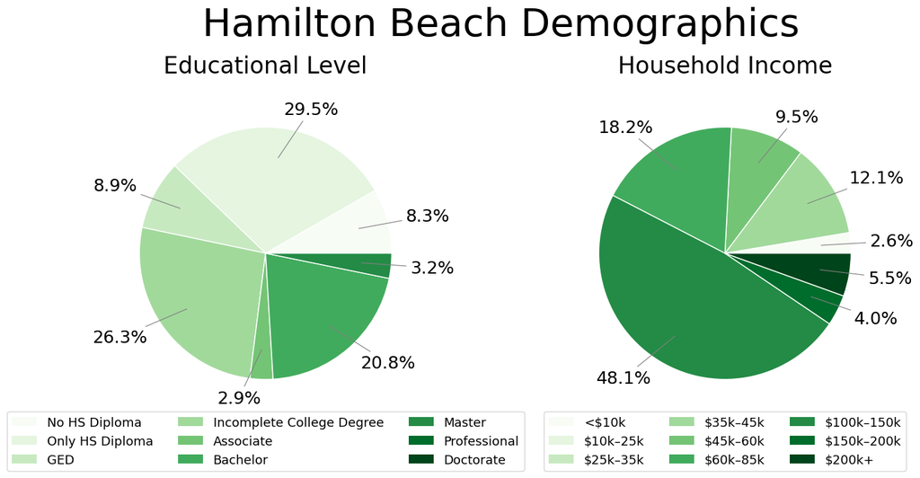

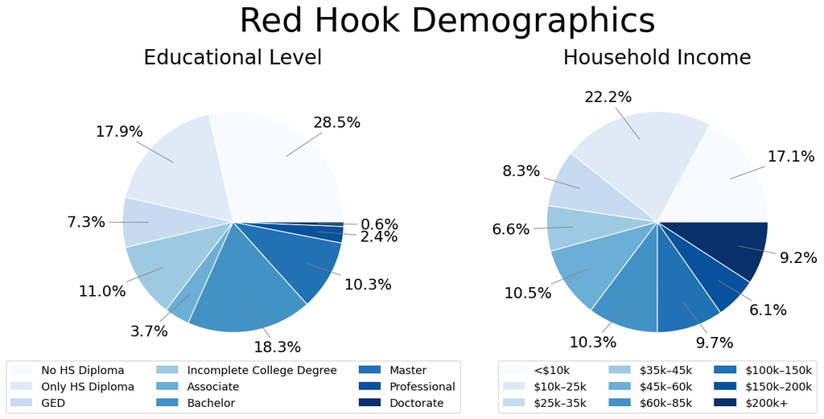

```python
import pandas as pd
import numpy as np
import matplotlib.pyplot as plt
import matplotlib.cm as cm
from matplotlib.patches import Patch

df = pd.read_csv(r'F:\dsl_CLIMA\projects\submittable\clima\source\census demographic files\nhgis0004_ds267_20235_blck_grp.csv', dtype={'TL_GEO_ID': str})

# GEOID groups
ham_beach = ['360810884006']
red_hook = [
    '360470053031', '360470053011', '360470053012', '360470053022',
    '360470085003', '360470059002', '360470059001', '360470085001',
    '360470085002', '360470053021', '360470053023'
]

# Filter data
ham_df = df[df['TL_GEO_ID'].isin(ham_beach)]
red_df = df[df['TL_GEO_ID'].isin(red_hook)]

# Education and income columns
edu_cols = [f"ASP3E{str(i).zfill(3)}" for i in range(2, 26)]
income_cols = [f"ASQOE{str(i).zfill(3)}" for i in range(2, 18)]

# Sum values
ham_edu_dist = ham_df[edu_cols].sum()
red_edu_dist = red_df[edu_cols].sum()
ham_income_dist = ham_df[income_cols].sum()
red_income_dist = red_df[income_cols].sum()

# Simplified education mapping
simplified_edu_groups = {
    "No HS Diploma": list(range(0, 15)),
    "Only HS Diploma": [15],
    "GED": [16],
    "Incomplete College Degree": [17, 18],
    "Associate": [19],
    "Bachelor": [20],
    "Master": [21],
    "Professional": [22],
    "Doctorate": [23]
}

def simplify_education_distribution(data):
    simplified = {}
    for label, indices in simplified_edu_groups.items():
        simplified[label] = data.iloc[indices].sum()
    return pd.Series(simplified)

# Apply simplification
ham_edu_simple = simplify_education_distribution(ham_edu_dist)
red_edu_simple = simplify_education_distribution(red_edu_dist)

merged_income_labels = [
    "<$10k", "$10k–25k", "$25k–35k", "$35k–45k", "$45k–60k",
    "$60k–85k", "$100k–150k", "$150k–200k", "$200k+"
]

# Mapping from ASQOE002–ASQOE017 (i.e., index 0–15)
merged_income_groups = {
    "<$10k": [0],                    # ASQOE002
    "$10k–25k": [1, 2, 3],           # ASQOE003 to ASQOE005
    "$25k–35k": [4, 5],              # ASQOE006 to ASQOE007
    "$35k–45k": [6, 7],              # ASQOE008 to ASQOE009
    "$45k–60k": [8, 9],              # ASQOE010 to ASQOE011
    "$60k–85k": [10, 11],            # ASQOE012 to ASQOE013
    "$100k–150k": [12, 13],          # ASQOE014 to ASQOE015
    "$150k–200k": [14],              # ASQOE016
    "$200k+": [15]                   # ASQOE017
}

def simplify_income_distribution(data):
    simplified = {}
    for label, indices in merged_income_groups.items():
        simplified[label] = data.iloc[indices].sum()
    return pd.Series(simplified)

ham_income_simple = simplify_income_distribution(ham_income_dist)
red_income_simple = simplify_income_distribution(red_income_dist)

def plot_pie(data, labels, title, palette='Blues', ax=None, radius=1.6):
    data = data.fillna(0)

    if len(data) != len(labels):
        print(f"Warning: Mismatch between data and labels for {title}")
        return

    # Logical orderings
    edu_order = [
        "No HS Diploma", "Only HS Diploma", "GED", "Incomplete College Degree",
        "Associate", "Bachelor", "Master", "Professional", "Doctorate"
    ]
    income_order = [
        "<$10k", "$10k–25k", "$25k–35k", "$35k–45k", "$45k–60k",
        "$60k–85k", "$100k–150k", "$150k–200k", "$200k+"
    ]
    if all(label in edu_order for label in labels):
        logical_order = edu_order
    elif all(label in income_order for label in labels):
        logical_order = income_order
    else:
        logical_order = sorted(labels)

    # Colormap and full label-color mapping
    cmap = cm.get_cmap(palette, len(logical_order))
    label_color_map = {label: cmap(i) for i, label in enumerate(logical_order)}

    # Data and colors for non-zero slices
    data_nonzero = data[data > 0]
    sorted_labels = [label for label in logical_order if label in data_nonzero.index]
    sorted_data = [data[label] for label in sorted_labels]
    sorted_colors = [label_color_map[label] for label in sorted_labels]

    if ax is None:
        fig, ax = plt.subplots(figsize=(8, 6))
    else:
        fig = ax.figure

    if not sorted_data:
        ax.text(0.5, 0.5, "No Data", ha="center", va="center", fontsize=14)
        ax.axis('off')
        return

    wedges, _ = ax.pie(
        sorted_data,
        colors=sorted_colors,
        startangle=0,
        labels=None,
        radius=radius,
        wedgeprops=dict(edgecolor='white')
    )

    total = sum(sorted_data)

    for wedge, val in zip(wedges, sorted_data):
        angle = (wedge.theta2 + wedge.theta1) / 2
        x = np.cos(np.radians(angle))
        y = np.sin(np.radians(angle))
        ha = 'left' if x > 0 else 'right'
        pct = f"{100 * val / total:.1f}%"

        label_pos = radius * 1.15
        arrow_start = radius * 0.75

        ax.annotate(
            pct,
            xy=(x * arrow_start, y * arrow_start),
            xytext=(x * label_pos, y * label_pos),
            ha=ha,
            va='center',
            fontsize=18,
            arrowprops=dict(arrowstyle='-', color='gray', lw=0.8),
            color='black'
        )

    # Legend: all categories, not just shown ones
    legend_labels = [label for label in logical_order if label in labels]
    legend_patches = [
        Patch(facecolor=label_color_map[label], edgecolor='none') for label in legend_labels
    ]

    ax.legend(
        legend_patches,
        legend_labels,
        loc='upper center',
        bbox_to_anchor=(0.5, 0),
        ncol=3,
        fontsize=13,
        labelcolor='black'
    )

    ax.set_title(title, fontsize=24, pad=30)
    ax.axis('equal')
    # plt.subplots_adjust(left=0.05, right=0.65, top=0.85, bottom=0.05)


edu_labels = [
        "No HS", "Only HS", "GED", "Incomplete College Degree",
        "Associate", "Bachelor", "Master", "Professional", "Doctorate"
    ]
income_labels = [
        "<$10k", "$10k–25k", "$25k–35k", "$35k–45k", "$45k–60k",
        "$60k–85k", "$100k–150k", "$150k–200k", "$200k+"
    ]
# Hamilton Beach plots side-by-side (with smaller radius)
fig_ham, axes_ham = plt.subplots(1, 2, figsize=(14, 7))
plot_pie(ham_edu_simple, ham_edu_simple.index.tolist(), "Educational Level", palette='Greens', ax=axes_ham[0])
plot_pie(ham_income_simple, ham_income_simple.index.tolist(), "Household Income", palette='Greens', ax=axes_ham[1])
fig_ham.suptitle('Hamilton Beach Demographics', fontsize=40, x=.525)

plt.tight_layout()
plt.show()
fig_ham.savefig('F:\\dsl_CLIMA\\projects\\submittable\\clima\\plots\\demographics\\pi charts\\hamBeach_pi.png', dpi=800, bbox_inches='tight')
# Red Hook plots side-by-side (default radius)
fig_red, axes_red = plt.subplots(1, 2, figsize=(14, 7))
plot_pie(red_edu_simple, red_edu_simple.index.tolist(), "Educational Level", palette='Blues', ax=axes_red[0])
plot_pie(red_income_simple, red_income_simple.index.tolist(), "Household Income", palette='Blues', ax=axes_red[1])
fig_red.suptitle('Red Hook Demographics', fontsize=40, x=.525)

plt.tight_layout()
plt.show()
fig_red.savefig('F:\\dsl_CLIMA\\projects\\submittable\\clima\\plots\\demographics\\pi charts\\redHook_pi.png', dpi=800, bbox_inches='tight')
```

# Results & Discussion

## Scaling Estimates Table

The fitted $\beta$ values across all four GEOID levels and all three network types are summarized below. CIs are 95% via the $t$-distribution with $N-2$ degrees of freedom.

| GEOID Type | GEOIDs | Network Type | β (Scaling Exponent) | γ (Intercept) | Exp. CI | Intercept CI | Adj. R² | Rescaled Degree | Avg Pop Est. | Avg 2022 User Est. |
| --- | --- | --- | --- | --- | --- | --- | --- | --- | --- | --- |
| County | 3141 | Total | 0.972 | 0.019 | [0.967,0.977] | [0.015,0.024] | 0.979 | 115,046,176 |  |  |
| County | 3141 | Inner | 1.062 | -0.013 | [1.052,1.073] | [-0.022,-0.004] | 0.925 | 35,816,319 | 106,879 | 54,429 |
| County | 3141 | Outgoing | 0.945 | 0.024 | [0.939,0.950] | [0.020,0.029] | 0.975 | 79,229,857 |  |  |
| ------------ | -------- | -------------- | ------------------- | --------------- | --------------- | --------------- | --------- | ---------------- | -------------- | ------------------ |
| CBSA | 917 | Total | 0.979 | 0.009 | [0.967,0.990] | [0.000,0.017] | 0.969 | 369,646,071 |  |  |
| CBSA | 917 | Inner | 1.064 | -0.065 | [1.046,1.082] | [-0.079,-0.051] | 0.937 | 166,674,627 | 345,975 | 175,799 |
| CBSA | 917 | Outgoing | 0.924 | 0.047 | [0.913,0.936] | [0.039,0.056] | 0.966 | 202,971,443 |  |  |
| ------------ | -------- | -------------- | ------------------- | --------------- | --------------- | --------------- | --------- | ---------------- | -------------- | ------------------ |
| MSA | 381 | Total | 0.982 | 0.006 | [0.962,1.002] | [-0.006,0.017] | 0.962 | 806,430,257 |  |  |
| MSA | 381 | Inner | 1.082 | -0.048 | [1.049,1.114] | [-0.067,-0.028] | 0.919 | 372,823,802 | 760,791 | 385,411 |
| MSA | 381 | Outgoing | 0.914 | 0.033 | [0.894,0.933] | [0.021,0.045] | 0.958 | 433,696,455 |  |  |
| ------------ | -------- | -------------- | ------------------- | --------------- | --------------- | --------------- | --------- | ---------------- | -------------- | ------------------ |
| muSA | 536 | Total | 0.969 | -0.009 | [0.931,1.007] | [-0.018,0.000] | 0.821 | 59,170,744 |  |  |
| muSA | 536 | Inner | 1.054 | -0.029 | [0.994,1.113] | [-0.042,-0.016] | 0.694 | 20,139,486 | 51,115 | 26,802 |
| muSA | 536 | Outgoing | 0.921 | -0.007 | [0.883,0.960] | [-0.016,0.002] | 0.805 | 39,031,258 |  |  |
| ------------ | -------- | -------------- | ------------------- | --------------- | --------------- | --------------- | --------- | ---------------- | -------------- | ------------------ |

### Reading the scaling table

- **Inner connections are superlinear** at every GEOID level — $\beta_{\text{Inner}} \in [1.054, 1.082]$ — and the entire 95% CI sits *above* 1 at the County, CBSA, and MSA levels. This is the same qualitative finding as *Schläpfer et al.* (2014) for face-to-face / phone interactions within cities: the larger the place, the *more than proportionally* its residents interact with each other. Our point estimate at the County level ($\beta = 1.062$) is at the low end of what they report for European urban areas (typically $\beta \approx 1.1\!-\!1.2$), which we read as a real but modest superlinearity at U.S. county resolution.
- **Outgoing connections are sublinear** at every level — $\beta_{\text{Outgoing}} \in [0.914, 0.945]$ — and again the 95% CI excludes 1 at the County, CBSA, and MSA levels. Larger places generate *proportionally fewer* outgoing per-capita ties, which is consistent with denser local social networks crowding out long-range ties as a place grows.
- **Total connections sit just below 1** — $\beta_{\text{Total}} \in [0.969, 0.982]$ — i.e., the superlinearity of the inner ties is approximately, but not quite, cancelled by the sublinearity of the outgoing ties. The Total exponent is the closest of the three to exact linearity, which is intuitive: once you sum within and across, the total degree of a place should be *roughly* proportional to its population.
- **muSA fits are noisier** ($R^2 \approx 0.69\!-\!0.82$) than MSA fits ($R^2 \approx 0.92\!-\!0.96$). This is expected — micropolitan areas are smaller and span a narrower range of population, so the regression has less leverage. The muSA Total CI ($[0.931, 1.007]$) actually *includes* 1.0, so we cannot reject pure linearity for total connectivity in the micropolitan subsample.
- **Stability across GEOID types**: the fact that $\beta_{\text{Inner}}$, $\beta_{\text{Outgoing}}$, and $\beta_{\text{Total}}$ stay within a tight band as we change GEOID resolution (County $\to$ CBSA $\to$ MSA) is a sanity check on the rescaling procedure — the exponents are not artifacts of how we drew the geographic partition.

### What the histograms told us

Before fitting any regression, the connection / user / population histograms in the **Distributions** section confirm the assumptions we need:

- The **log-transformed** Inter-, Outgoing-, and Total-connection counts at all four GEOID levels are close to Normal in shape — i.e., the raw counts are roughly **log-normal**, which is the canonical distribution arising from multiplicative growth processes. This is precisely what justifies treating $\epsilon_i$ in the Basic Power Law as multiplicative noise and fitting in log-log space.
- The fitted Log-Normal PDF has the lowest RMSE vs. KDE for the bulk of variables, with the SkewNormal occasionally edging it out for the more right-skewed populations.
- The Generalized Pareto fit to the top 75% tail captures the heavy upper tail (the few outsize metros that dominate the absolute connection counts) without forcing the bulk distribution into a heavy-tailed family.

### What the choropleths told us

- The **raw connection choropleths** light up exactly where expected — BosWash, Chicago, the Bay Area + LA, Texas Triangle, Front Range, Florida — confirming that the absolute connection counts track population.
- The **coverage choropleth** ($s_i = |S_i|/N_i$) is more revealing: coverage spans roughly $0.34\!-\!0.63$ across counties, with higher coverage in dense, younger, more-online counties (urban Northeast, Pacific coast, parts of the Mountain West) and lower coverage in much of the rural South and Plains. This is exactly the kind of *geographically heterogeneous undercount* the *Schläpfer* rescaling step is designed to absorb.
- The **per-user choropleths** — connections divided by Facebook MAU — are visibly **flatter** than the raw-count choropleths. That's the qualitative confirmation that rescaling by $s_i$ has done its job: once we strip out the population-driven baseline, per-user connectivity is no longer dominated by where the people are.

### What the demographic figures told us

The Census-block analyses in the Demographics section sit at a completely different scale from the national regressions, but they're the bridge to the CLIMA application:

## Future Work

- **Mobility model with flood-risk benefits.** After reading [*A Universal Model for Mobility and Migration Patterns* (Simini et al., 2012)](https://doi.org/10.1038/nature10856), we began formulating a model using FEMA's National Risk Index as part of the benefit-distribution term, with the *ratio of available homes* (rather than the radiation model's ratio of available jobs) as the relevant opportunity surface for homeowner relocation decisions. The scaling exponents in this notebook are an empirical input to that model — they parameterize how *fast* information about flood events can propagate through a community of a given size.
- **Re-attempt community identification.** The Clique Percolation Method (CPM) on the symmetric ~10M-row edge list exhausted available RAM mid-build. A memory-frugal variant — e.g., Louvain on the bipartite county-user projection, or CPM restricted to within-CBSA edges — should be tractable on a higher-memory machine and would give us a third lens (mesoscale community structure) on top of the scaling and demographic analyses.
- **Broaden the demographic comparison.** Extend the block-level demographic snapshots beyond Hamilton Beach / Howard Beach / Red Hook to the full set of NYC waterfront census tracts under FEMA 100-year and 500-year designations, so the scaling and demographic strands can be joined into a single block-level vulnerability picture.
- **Cross-validate ESRI MAU.** ESRI's `MP19049a_B` is a model output; the most natural cross-check would be against state-level Pew Research surveys on Facebook adoption rates, which would let us calibrate the ~17% gap between our average $s_i$ and Meta's published MAU coverage figure.

## Potential Problems

- **County-level Facebook MAU is not publicly reported by Meta.** ESRI is our best stand-in, but comparing our derived average $s_i$ against Meta's published Q4 '22 MAU figure suggests the ESRI-derived coverage runs ~17% below the true MAU coverage. A uniform underestimate would shift the intercept $\gamma$ but leave $\beta$ unchanged in expectation; however, because ESRI's MAU model is itself geographically heterogeneous (undercounting more in certain county types than others), there is a second-order effect on $\beta$ that's harder to bound. The most plausible direction is a small *decrease* in $\beta$ — i.e., the true scaling is slightly *more* sublinear than what we report for Outgoing and Total.
- **SCI itself is noised.** Gaussian noise in $\pm[0,1]$ is added by Meta to the raw connection counts to preserve privacy. For large counties this is invisible, but for the lowest-user counties (just above the 50,000-user reporting threshold) it can dominate the signal — this is part of why the muSA confidence intervals are wider.
- **ESRI MAU is a model output**, not a direct count — so two layers of estimation (Meta's true MAU → ESRI's modeled MAU → our $|S_i|$) sit between the underlying truth and the regressor.
- **The demographic figures are descriptive.** Three communities ≠ a generalizable claim about coastal NYC. We use these blocks to ground the modeling work in concrete cases, not to extrapolate to broader populations.

## References

### Meta SCI Resources

- [SCI Homepage](https://data.humdata.org/dataset/social-connectedness-index)
- [SCI Methodology](https://dataforgood.facebook.com/dfg/docs/methodology-social-connectedness-index)
- [SCI Docs](https://data.humdata.org/dataset/e9988552-74e4-4ff4-943f-c782ac8bca87/resource/a0c37eb4-b45c-436d-b2b2-c0c9b1974318/download/documentation-fb-social-connectedness-index-october-2021.pdf)
- [County-to-County SCI Dataset](https://data.humdata.org/dataset/e9988552-74e4-4ff4-943f-c782ac8bca87/resource/c59fd5ac-0458-4e83-b6be-5334f0ea9a69/download/us-counties-us-counties-fb-social-connectedness-index-october-2021.zip)

### Meta Official Regional Coverage Estimates

- [Meta Q4 '22 Earnings Presentation](https://s21.q4cdn.com/399680738/files/doc_financials/2023/q4/Earnings-Presentation-Q4-2023.pdf)

### ESRI Facebook User Estimates

- [ESRI Data](https://nyuds.maps.arcgis.com/home/item.html?id=14a2fb32e22b4fe5ab9d884c9e994075)
- [ESRI Documentation](https://demographics5.arcgis.com/arcgis/rest/services/USA_MPI_1_2022/MapServer/7)

### Crosswalk

- [County-MSA-CSA Crosswalk](https://www.bls.gov/cew/classifications/areas/county-msa-csa-crosswalk.html)

### Census / Demographic Data

- [IPUMS NHGIS — 2020 DHC and ACS extracts](https://www.nhgis.org/)
- [TIGER/Line Shapefiles (2021)](https://www.census.gov/geographies/mapping-files/time-series/geo/tiger-line-file.html)

## Bibliography

1. Bailey, Michael, Rachel Cao, Theresa Kuchler, Johannes Stroebel, and Arlene Wong. **"Social Connectedness: Measurement, Determinants, and Effects."** *Journal of Economic Perspectives* 32, no. 3 (August 2018): 259-280. DOI: 10.1257/jep.32.3.259
2. Schläpfer, M., Bettencourt, L. M. A., Grauwin, S., Raschke, M., Claxton, R., Smoreda, Z., West, G. B., & Ratti, C. (2014). **The scaling of human interactions with city size.** *Journal of the Royal Society Interface*, **11**(98), 20130789. DOI: 10.1098/rsif.2013.0789
3. Simini, F., González, M., Maritan, A., et al. **A universal model for mobility and migration patterns.** *Nature* **484**, 96-100 (2012). DOI: 10.1038/nature10856

al fin :]